# FIA NLS Models: Biomass vs. Stand Age (Temporally-Balanced dataset) – with Biomass Partitioning for the Eastern US

JAH

2023-07-18

# Background

This analysis document compliments **FIA NLS Models: Biomass vs. Stand Age**. All of the background information from that document applies to these analyses, which are extensions to them. In this analysis, we fit models to the temporally-balanced dataset, which uses the first and most-recent plot re-measurement for each FIA plot. Then, we conduct a model bookeeping analysis, which does biomass change attribution to:

1. age-related biomass change
2. productivity-trend driven biomass change
3. disturbance regime (changes in the biomass loss rate)- attributable biomass change

Below the model fitting procedure is implemented by ecoprovince:

# Using temporally-balanced data

## 211 - Northeastern Mixed Forest

### model selection 1

```
## Analysis of Variance Table
##
## Model 1: B_plt_t2_MgHa ~ (1 + (MEASTIME_t2 - 1990) * tau/100) * A * STDAGE_t2/(k + STDAGE_t2)
## Model 2: B_plt_t2_MgHa ~ (1 + (MEASTIME_t2 - 1990) * tau/100) * (1 - alpha * B_L_prop) * A * STDAGE_t2/(k + STDAGE_t2)
##   Res.Df Res.Sum Sq Df Sum Sq F value    Pr(>F)
## 1   4834     1203.6
## 2   4833     1092.6  1 111.05  491.22 < 2.2e-16 ***
## ---
## Signif. codes:  0 '***' 0.001 '**' 0.01 '*' 0.05 '.' 0.1 ' ' 1
##   model      AIC
## 1     1 52557.62
## 2     2 52091.41
```

```
##
## Formula: B_plt_t2_MgHa ~ (1 + (MEASTIME_t2 - 1990) * tau/100) * (1 - alpha *
##     B_L_prop) * A * STDAGE_t2/(k + STDAGE_t2)
##
## Parameters:
##        Estimate Std. Error t value Pr(>|t|)
## tau     0.45951    0.16992   2.704  0.00687 **
## alpha   0.84855    0.03503  24.221  < 2e-16 ***
## A     473.76484   37.00356  12.803  < 2e-16 ***
## k     205.69316   18.21698  11.291  < 2e-16 ***
## ---
## Signif. codes:  0 '***' 0.001 '**' 0.01 '*' 0.05 '.' 0.1 ' ' 1
##
## Residual standard error: 0.4755 on 4833 degrees of freedom
##
## Number of iterations to convergence: 7
## Achieved convergence tolerance: 2.017e-06
##   (1 observation deleted due to missingness)
```

#### summary

- simple model: fits
- alpha model: fits

### model selection 2

```
## Error in Mod.Sel3 %in% c(1, "1a", "1b", "1c", 4) :
##   object 'Mod.Sel3' not found
## Error in Mod.Sel3 %in% c(1, "1a", "1b", "1c", 4) :
##   object 'Mod.Sel3' not found
## Error in Mod.Sel3 %in% c(1, "1a", "1b", "1c", 4) :
##   object 'Mod.Sel3' not found
##   model      AIC
## 1     2 52091.41
## 2    2a       NA
## 3    2b       NA
## 4    2c       NA
```

```
##
## Formula: B_plt_t2_MgHa ~ (1 + (MEASTIME_t2 - 1990) * tau/100) * (1 - alpha *
##     B_L_prop) * A * STDAGE_t2/(k + STDAGE_t2)
##
## Parameters:
##        Estimate Std. Error t value Pr(>|t|)
## tau     0.45951    0.16992   2.704  0.00687 **
## alpha   0.84855    0.03503  24.221  < 2e-16 ***
## A     473.76484   37.00356  12.803  < 2e-16 ***
## k     205.69316   18.21698  11.291  < 2e-16 ***
## ---
## Signif. codes:  0 '***' 0.001 '**' 0.01 '*' 0.05 '.' 0.1 ' ' 1
##
## Residual standard error: 0.4755 on 4833 degrees of freedom
##
## Number of iterations to convergence: 7
## Achieved convergence tolerance: 2.017e-06
##   (1 observation deleted due to missingness)
```

### summary

- add p model: does not fit
- add s model: does not fit
- add s+p model: does not fit

### model selection 3

```
## Analysis of Variance Table
##
## Model 1: B_plt_t2_MgHa ~ (1 + (MEASTIME_t2 - 1990) * tau/100) * (a + b * exp(-((log(STDAGE_t2/c))/d)^2))
## Model 2: B_plt_t2_MgHa ~ (1 + (MEASTIME_t2 - 1990) * tau/100) * (1 - alpha * B_L_prop) * (a + b * exp(-((log(STDAGE_t2/c))/d)^2))
##   Res.Df Res.Sum Sq Df Sum Sq F value    Pr(>F)
## 1   4832     1179.6
## 2   4831     1067.7  1 111.87  506.17 < 2.2e-16 ***
## ---
## Signif. codes:  0 '***' 0.001 '**' 0.01 '*' 0.05 '.' 0.1 ' ' 1
##   model      AIC
## 1     2 52091.41
## 2     4 52463.90
## 3     5 51983.93
```

```
##
## Formula: B_plt_t2_MgHa ~ (1 + (MEASTIME_t2 - 1990) * tau/100) * (1 - alpha *
##     B_L_prop) * (a + b * exp(-((log(STDAGE_t2/c))/d)^2))
##
## Parameters:
##        Estimate Std. Error t value Pr(>|t|)
## tau     0.58118    0.17752   3.274  0.00107 **
## alpha   0.84078    0.03411  24.646  < 2e-16 ***
## a      33.40070    1.99286  16.760  < 2e-16 ***
## b     118.88478    5.92661  20.059  < 2e-16 ***
## c     118.37512    5.85956  20.202  < 2e-16 ***
## d       1.01653    0.05233  19.425  < 2e-16 ***
## ---
## Signif. codes:  0 '***' 0.001 '**' 0.01 '*' 0.05 '.' 0.1 ' ' 1
##
## Residual standard error: 0.4701 on 4831 degrees of freedom
##
## Algorithm "port", convergence message: relative convergence (4)
##   (1 observation deleted due to missingness)
```

#### summary

- simple log-normal model: fits
- log-normal phi model: fits

### predict and plot

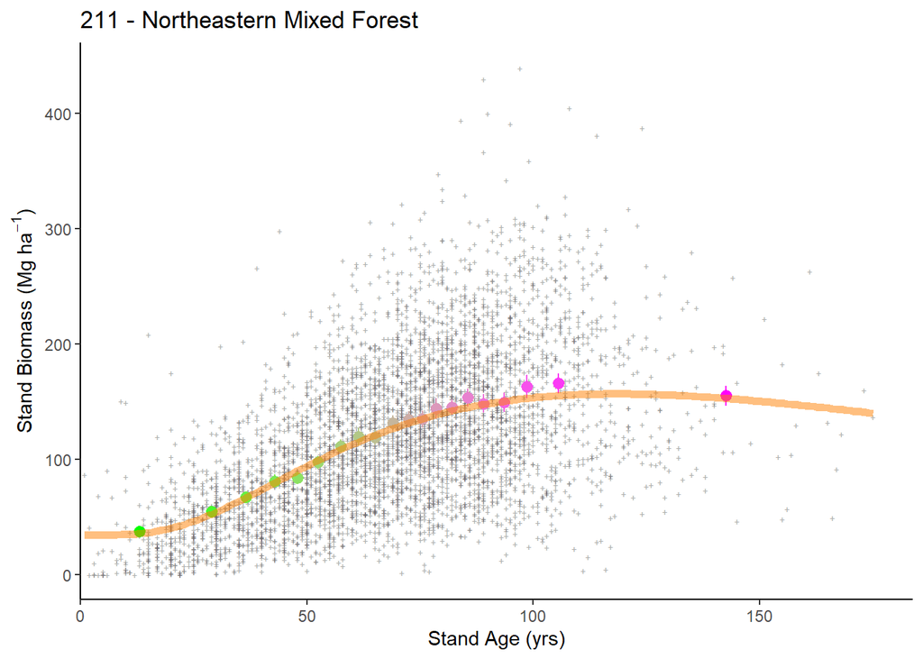

### plotting 2

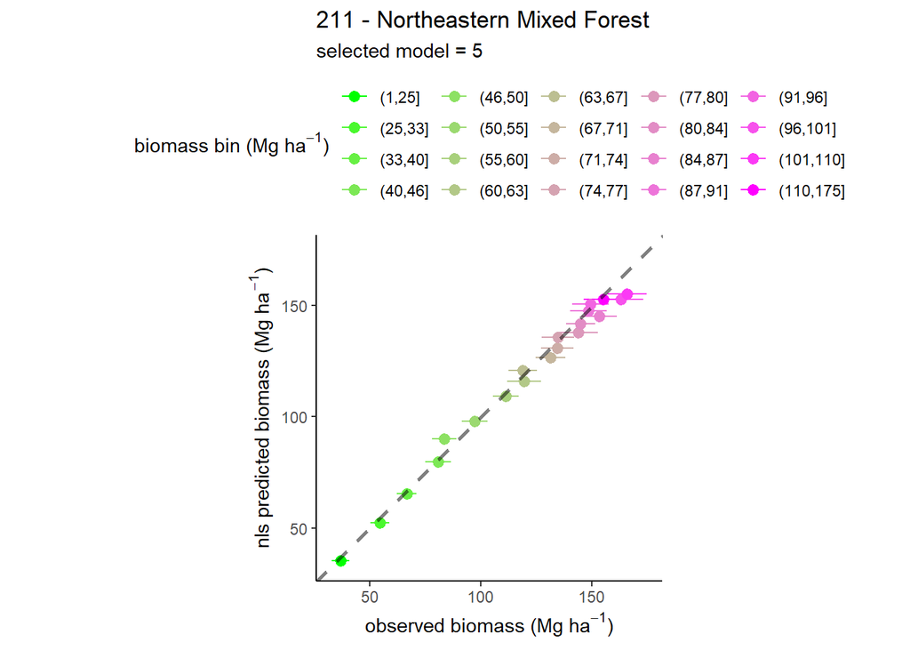

## 212 - Laurentian Mixed Forest

### model selection 1

```
## Analysis of Variance Table
##
## Model 1: B_plt_t2_MgHa ~ (1 + (MEASTIME_t2 - 1990) * tau/100) * A * STDAGE_t2/(k + STDAGE_t2)
## Model 2: B_plt_t2_MgHa ~ (1 + (MEASTIME_t2 - 1990) * tau/100) * (1 - alpha * B_L_prop) * A * STDAGE_t2/(k + STDAGE_t2)
##   Res.Df Res.Sum Sq Df Sum Sq F value    Pr(>F)
## 1  12943     5165.4
## 2  12942     5044.1  1 121.33   311.3 < 2.2e-16 ***
## ---
## Signif. codes:  0 '***' 0.001 '**' 0.01 '*' 0.05 '.' 0.1 ' ' 1
##   model      AIC
## 1     1 135621.4
## 2     2 135315.7
```

```
##
## Formula: B_plt_t2_MgHa ~ (1 + (MEASTIME_t2 - 1990) * tau/100) * (1 - alpha *
##     B_L_prop) * A * STDAGE_t2/(k + STDAGE_t2)
##
## Parameters:
##        Estimate Std. Error t value Pr(>|t|)
## tau     0.95237    0.12759   7.464 8.91e-14 ***
## alpha   0.62169    0.03318  18.736  < 2e-16 ***
## A     165.96924    5.63575  29.449  < 2e-16 ***
## k      78.87707    3.15407  25.008  < 2e-16 ***
## ---
## Signif. codes:  0 '***' 0.001 '**' 0.01 '*' 0.05 '.' 0.1 ' ' 1
##
## Residual standard error: 0.6243 on 12942 degrees of freedom
##
## Number of iterations to convergence: 4
## Achieved convergence tolerance: 8.623e-06
##   (16 observations deleted due to missingness)
```

#### summary

- simple model: fits
- alpha model: fits

### model selection 2

```
## Error in numericDeriv(form[[3L]], names(ind), env, central = nDcentral) :
##   Missing value or an infinity produced when evaluating the model
## Analysis of Variance Table
##
## Model 1: B_plt_t2_MgHa ~ (1 + (MEASTIME_t2 - 1990) * tau/100) * (1 - alpha * B_L_prop) * A * STDAGE_t2/(k + STDAGE_t2)
## Model 2: B_plt_t2_MgHa ~ (1 + (MEASTIME_t2 - 1990) * tau/100) * (1 - alpha * B_L_prop) * (p * A + ((1 - p) * A * STDAGE_t2/(k + STDAGE_t2)))
##   Res.Df Res.Sum Sq Df Sum Sq F value    Pr(>F)
## 1  12942     5044.1
## 2  12941     5021.8  1 22.266  57.378 3.839e-14 ***
## ---
## Signif. codes:  0 '***' 0.001 '**' 0.01 '*' 0.05 '.' 0.1 ' ' 1
##   model      AIC
## 1     2 135315.7
## 2    2a 135260.4
## 3    2b 135317.6
## 4    2c       NA
```

```
##
## Formula: B_plt_t2_MgHa ~ (1 + (MEASTIME_t2 - 1990) * tau/100) * (1 - alpha *
##     B_L_prop) * (p * A + ((1 - p) * A * STDAGE_t2/(k + STDAGE_t2)))
##
## Parameters:
##        Estimate Std. Error t value Pr(>|t|)
## tau   9.238e-01  1.259e-01   7.336 2.33e-13 ***
## alpha 6.214e-01  3.094e-02  20.082  < 2e-16 ***
## A     1.921e+02  9.346e+00  20.559  < 2e-16 ***
## k     1.085e+02  7.979e+00  13.593  < 2e-16 ***
## p     2.121e-02  2.492e-03   8.509  < 2e-16 ***
## ---
## Signif. codes:  0 '***' 0.001 '**' 0.01 '*' 0.05 '.' 0.1 ' ' 1
##
## Residual standard error: 0.6229 on 12941 degrees of freedom
##
## Number of iterations to convergence: 9
## Achieved convergence tolerance: 5.063e-06
##   (16 observations deleted due to missingness)
```

### summary

- add p model: fits
- add s model: fits
- add s+p model: does not fit

### model selection 3

```
## Analysis of Variance Table
##
## Model 1: B_plt_t2_MgHa ~ (1 + (MEASTIME_t2 - 1990) * tau/100) * (a + b * exp(-((log(STDAGE_t2/c))/d)^2))
## Model 2: B_plt_t2_MgHa ~ (1 + (MEASTIME_t2 - 1990) * tau/100) * (1 - alpha * B_L_prop) * (a + b * exp(-((log(STDAGE_t2/c))/d)^2))
##   Res.Df Res.Sum Sq Df Sum Sq F value    Pr(>F)
## 1  12941     5088.9
## 2  12940     4912.4  1 176.51  464.95 < 2.2e-16 ***
## ---
## Signif. codes:  0 '***' 0.001 '**' 0.01 '*' 0.05 '.' 0.1 ' ' 1
##   model      AIC
## 1    2a 135260.4
## 2     4 135432.3
## 3     5 134977.3
```

```
##
## Formula: B_plt_t2_MgHa ~ (1 + (MEASTIME_t2 - 1990) * tau/100) * (1 - alpha *
##     B_L_prop) * (a + b * exp(-((log(STDAGE_t2/c))/d)^2))
##
## Parameters:
##        Estimate Std. Error t value Pr(>|t|)
## tau     1.19051    0.13607   8.749   <2e-16 ***
## alpha   0.67333    0.02702  24.922   <2e-16 ***
## a      13.38590    0.51341  26.073   <2e-16 ***
## b      75.80154    2.36631  32.034   <2e-16 ***
## c     121.05709    5.45544  22.190   <2e-16 ***
## d       1.41595    0.04287  33.030   <2e-16 ***
## ---
## Signif. codes:  0 '***' 0.001 '**' 0.01 '*' 0.05 '.' 0.1 ' ' 1
##
## Residual standard error: 0.6161 on 12940 degrees of freedom
##
## Algorithm "port", convergence message: relative convergence (4)
##   (16 observations deleted due to missingness)
```

#### summary

- simple log-normal model: fits
- log-normal phi model: fits

### predict and plot

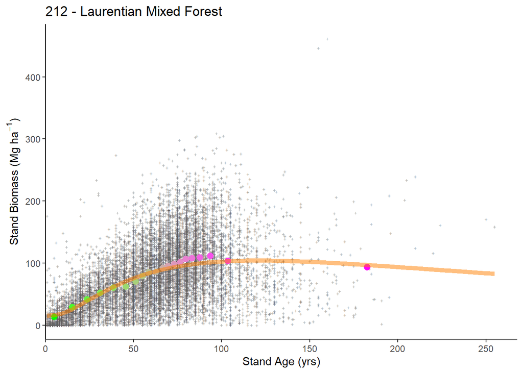

### plotting 2

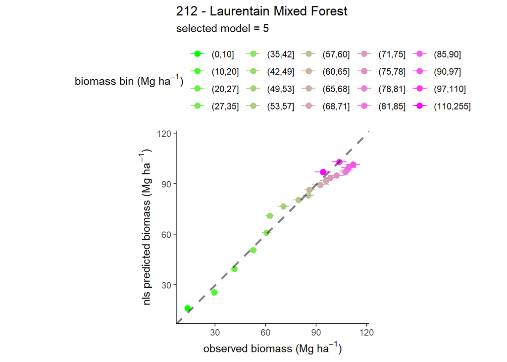

## 221 - Eastern Broadleaf Forest

### model selection 1

```
## Analysis of Variance Table
##
## Model 1: B_plt_t2_MgHa ~ (1 + (MEASTIME_t2 - 1990) * tau/100) * A * STDAGE_t2/(k + STDAGE_t2)
## Model 2: B_plt_t2_MgHa ~ (1 + (MEASTIME_t2 - 1990) * tau/100) * (1 - alpha * B_L_prop) * A * STDAGE_t2/(k + STDAGE_t2)
##   Res.Df Res.Sum Sq Df Sum Sq F value    Pr(>F)
## 1   5442     948.80
## 2   5441     857.87  1 90.926  576.69 < 2.2e-16 ***
## ---
## Signif. codes:  0 '***' 0.001 '**' 0.01 '*' 0.05 '.' 0.1 ' ' 1
##   model      AIC
## 1     1 59550.63
## 2     2 59004.09
```

```
##
## Formula: B_plt_t2_MgHa ~ (1 + (MEASTIME_t2 - 1990) * tau/100) * (1 - alpha *
##     B_L_prop) * A * STDAGE_t2/(k + STDAGE_t2)
##
## Parameters:
##       Estimate Std. Error t value Pr(>|t|)
## tau     0.1644     0.1261   1.304    0.192
## alpha   0.8050     0.0312  25.799   <2e-16 ***
## A     500.5614    30.8115  16.246   <2e-16 ***
## k     155.6108    11.1725  13.928   <2e-16 ***
## ---
## Signif. codes:  0 '***' 0.001 '**' 0.01 '*' 0.05 '.' 0.1 ' ' 1
##
## Residual standard error: 0.3971 on 5441 degrees of freedom
##
## Number of iterations to convergence: 7
## Achieved convergence tolerance: 2.272e-06
##   (1 observation deleted due to missingness)
```

#### summary

- simple model: fits
- alpha model: fits

### model selection 2

```
## Error in numericDeriv(form[[3L]], names(ind), env, central = nDcentral) :
##   Missing value or an infinity produced when evaluating the model
## Analysis of Variance Table
##
## Model 1: B_plt_t2_MgHa ~ (1 + (MEASTIME_t2 - 1990) * tau/100) * (1 - alpha * B_L_prop) * A * STDAGE_t2/(k + STDAGE_t2)
## Model 2: B_plt_t2_MgHa ~ (1 + (MEASTIME_t2 - 1990) * tau/100) * (1 - alpha * B_L_prop) * (p * A + ((1 - p) * A * STDAGE_t2/(k + STDAGE_t2)))
##   Res.Df Res.Sum Sq Df Sum Sq F value  Pr(>F)
## 1   5441     857.87
## 2   5440     856.53  1 1.3429   8.529 0.00351 **
## ---
## Signif. codes:  0 '***' 0.001 '**' 0.01 '*' 0.05 '.' 0.1 ' ' 1
##   model      AIC
## 1     2 59004.09
## 2    2a 58997.56
## 3    2b 58973.93
## 4    2c       NA
```

```
##
## Formula: B_plt_t2_MgHa ~ (1 + (MEASTIME_t2 - 1990) * tau/100) * (1 - alpha *
##     B_L_prop) * (A * STDAGE_t2^s/(k^s + STDAGE_t2^s))
##
## Parameters:
##        Estimate Std. Error t value Pr(>|t|)
## tau     0.23383    0.13009   1.797   0.0723 .
## alpha   0.81624    0.03142  25.975   <2e-16 ***
## A     293.53650   21.44552  13.688   <2e-16 ***
## k      64.20469    6.41740  10.005   <2e-16 ***
## s       1.31952    0.05962  22.132   <2e-16 ***
## ---
## Signif. codes:  0 '***' 0.001 '**' 0.01 '*' 0.05 '.' 0.1 ' ' 1
##
## Residual standard error: 0.3959 on 5440 degrees of freedom
##
## Number of iterations to convergence: 7
## Achieved convergence tolerance: 2.275e-06
##   (1 observation deleted due to missingness)
```

### summary

- add p model: fits
- add s model: fits
- add s+p model: does not fit

### model selection 3

```
## Analysis of Variance Table
##
## Model 1: B_plt_t2_MgHa ~ (1 + (MEASTIME_t2 - 1990) * tau/100) * (a + b * exp(-((log(STDAGE_t2/c))/d)^2))
## Model 2: B_plt_t2_MgHa ~ (1 + (MEASTIME_t2 - 1990) * tau/100) * (1 - alpha * B_L_prop) * (a + b * exp(-((log(STDAGE_t2/c))/d)^2))
##   Res.Df Res.Sum Sq Df Sum Sq F value    Pr(>F)
## 1   5440     940.37
## 2   5439     848.31  1 92.062  590.26 < 2.2e-16 ***
## ---
## Signif. codes:  0 '***' 0.001 '**' 0.01 '*' 0.05 '.' 0.1 ' ' 1
##   model      AIC
## 1    2b 58973.93
## 2     4 59506.03
## 3     5 58947.03
```

```
##
## Formula: B_plt_t2_MgHa ~ (1 + (MEASTIME_t2 - 1990) * tau/100) * (1 - alpha *
##     B_L_prop) * (a + b * exp(-((log(STDAGE_t2/c))/d)^2))
##
## Parameters:
##        Estimate Std. Error t value Pr(>|t|)
## tau     0.24222    0.13018   1.861   0.0629 .
## alpha   0.80822    0.03087  26.178  < 2e-16 ***
## a      21.08256    2.67854   7.871 4.22e-15 ***
## b     179.51639   10.45102  17.177  < 2e-16 ***
## c     156.83930   15.71326   9.981  < 2e-16 ***
## d       1.51879    0.08979  16.915  < 2e-16 ***
## ---
## Signif. codes:  0 '***' 0.001 '**' 0.01 '*' 0.05 '.' 0.1 ' ' 1
##
## Residual standard error: 0.3949 on 5439 degrees of freedom
##
## Algorithm "port", convergence message: relative convergence (4)
##   (1 observation deleted due to missingness)
```

#### summary

- simple log-normal model: fits
- log-normal phi model: fits

### predict and plot

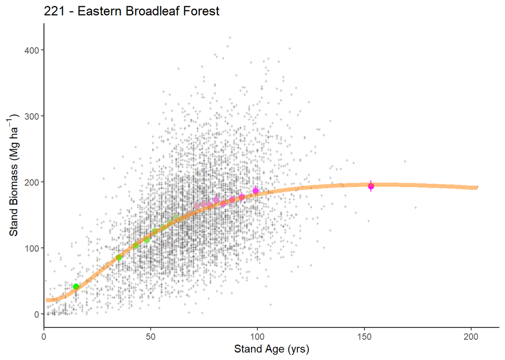

### plotting 2

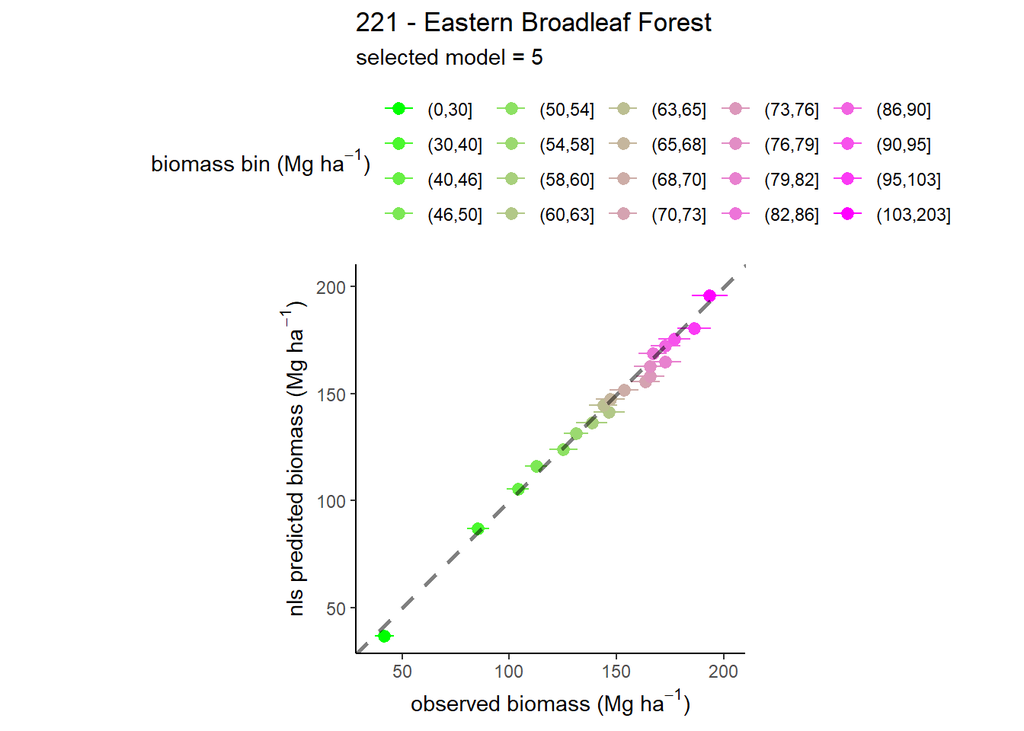

## 222 - Midwest Broadleaf Forest

### model selection 1

```
## Analysis of Variance Table
##
## Model 1: B_plt_t2_MgHa ~ (1 + (MEASTIME_t2 - 1990) * tau/100) * A * STDAGE_t2/(k + STDAGE_t2)
## Model 2: B_plt_t2_MgHa ~ (1 + (MEASTIME_t2 - 1990) * tau/100) * (1 - alpha * B_L_prop) * A * STDAGE_t2/(k + STDAGE_t2)
##   Res.Df Res.Sum Sq Df Sum Sq F value    Pr(>F)
## 1   3547     1178.6
## 2   3546     1136.5  1 42.068  131.25 < 2.2e-16 ***
## ---
## Signif. codes:  0 '***' 0.001 '**' 0.01 '*' 0.05 '.' 0.1 ' ' 1
```

```
##   model      AIC
## 1     1 38157.03
## 2     2 38030.00
```

```
##
## Formula: B_plt_t2_MgHa ~ (1 + (MEASTIME_t2 - 1990) * tau/100) * (1 - alpha *
##     B_L_prop) * A * STDAGE_t2/(k + STDAGE_t2)
##
## Parameters:
##        Estimate Std. Error t value Pr(>|t|)
## tau     1.03509    0.24350   4.251 2.18e-05 ***
## alpha   0.72686    0.05912  12.295  < 2e-16 ***
## A     445.56009   55.43529   8.037 1.24e-15 ***
## k     254.71684   34.82136   7.315 3.17e-13 ***
## ---
## Signif. codes:  0 '***' 0.001 '**' 0.01 '*' 0.05 '.' 0.1 ' ' 1
##
## Residual standard error: 0.5661 on 3546 degrees of freedom
##
## Number of iterations to convergence: 8
## Achieved convergence tolerance: 2.413e-06
##   (2 observations deleted due to missingness)
```

#### summary

- simple model: fits
- alpha model: fits

### model selection 2

```
## Error in numericDeriv(form[[3L]], names(ind), env, central = nDcentral) :
##   Missing value or an infinity produced when evaluating the model
## Error in numericDeriv(form[[3L]], names(ind), env, central = nDcentral) :
##   Missing value or an infinity produced when evaluating the model
## Analysis of Variance Table
##
## Model 1: B_plt_t2_MgHa ~ (1 + (MEASTIME_t2 - 1990) * tau/100) * (1 - alpha * B_L_prop) * A * STDAGE_t2/(k + STDAGE_t2)
## Model 2: B_plt_t2_MgHa ~ (1 + (MEASTIME_t2 - 1990) * tau/100) * (1 - alpha * B_L_prop) * (p * A + ((1 - p) * A * STDAGE_t2/(k + STDAGE_t2)))
##   Res.Df Res.Sum Sq Df Sum Sq F value  Pr(>F)
## 1   3546     1136.5
## 2   3545     1132.9  1 3.5914  11.238 0.00081 ***
## ---
## Signif. codes:  0 '***' 0.001 '**' 0.01 '*' 0.05 '.' 0.1 ' ' 1
##   model      AIC
## 1     2 38030.00
## 2    2a 38020.77
## 3    2b       NA
## 4    2c       NA
```

```
##
## Formula: B_plt_t2_MgHa ~ (1 + (MEASTIME_t2 - 1990) * tau/100) * (1 - alpha *
##     B_L_prop) * (p * A + ((1 - p) * A * STDAGE_t2/(k + STDAGE_t2)))
##
## Parameters:
##         Estimate Std. Error t value Pr(>|t|)
## tau     1.091545   0.248065   4.400 1.11e-05 ***
## alpha   0.753308   0.059393  12.683  < 2e-16 ***
## A     342.271688  43.589966   7.852 5.38e-15 ***
## k     170.045425  28.883552   5.887 4.29e-09 ***
## p      -0.015140   0.006514  -2.324   0.0202 *
## ---
## Signif. codes:  0 '***' 0.001 '**' 0.01 '*' 0.05 '.' 0.1 ' ' 1
##
## Residual standard error: 0.5653 on 3545 degrees of freedom
##
## Number of iterations to convergence: 10
## Achieved convergence tolerance: 5.957e-06
##   (2 observations deleted due to missingness)
```

### summary

- add p model: fits
- add s model: does not fit
- add s+p model: does not fit

### model selection 3

```
## Analysis of Variance Table
##
## Model 1: B_plt_t2_MgHa ~ (1 + (MEASTIME_t2 - 1990) * tau/100) * (a + b * exp(-((log(STDAGE_t2/c))/d)^2))
## Model 2: B_plt_t2_MgHa ~ (1 + (MEASTIME_t2 - 1990) * tau/100) * (1 - alpha * B_L_prop) * (a + b * exp(-((log(STDAGE_t2/c))/d)^2))
##   Res.Df Res.Sum Sq Df Sum Sq F value    Pr(>F)
## 1   3545     1160.1
## 2   3544     1108.8  1 51.282  163.91 < 2.2e-16 ***
## ---
## Signif. codes:  0 '***' 0.001 '**' 0.01 '*' 0.05 '.' 0.1 ' ' 1
##   model      AIC
## 1    2a 38020.77
## 2     4 38104.80
## 3     5 37946.29
```

```
##
## Formula: B_plt_t2_MgHa ~ (1 + (MEASTIME_t2 - 1990) * tau/100) * (1 - alpha *
##     B_L_prop) * (a + b * exp(-((log(STDAGE_t2/c))/d)^2))
##
## Parameters:
##        Estimate Std. Error t value Pr(>|t|)
## tau     1.21145    0.25520   4.747 2.14e-06 ***
## alpha   0.76881    0.05439  14.134  < 2e-16 ***
## a      14.01898    1.39169  10.073  < 2e-16 ***
## b     101.92211    6.02465  16.918  < 2e-16 ***
## c     115.56990    8.21593  14.067  < 2e-16 ***
## d       1.19701    0.06667  17.955  < 2e-16 ***
## ---
## Signif. codes:  0 '***' 0.001 '**' 0.01 '*' 0.05 '.' 0.1 ' ' 1
##
## Residual standard error: 0.5593 on 3544 degrees of freedom
##
## Algorithm "port", convergence message: relative convergence (4)
##   (2 observations deleted due to missingness)
```

#### summary

- simple log-normal model: fits
- log-normal phi model: fits

### predict and plot

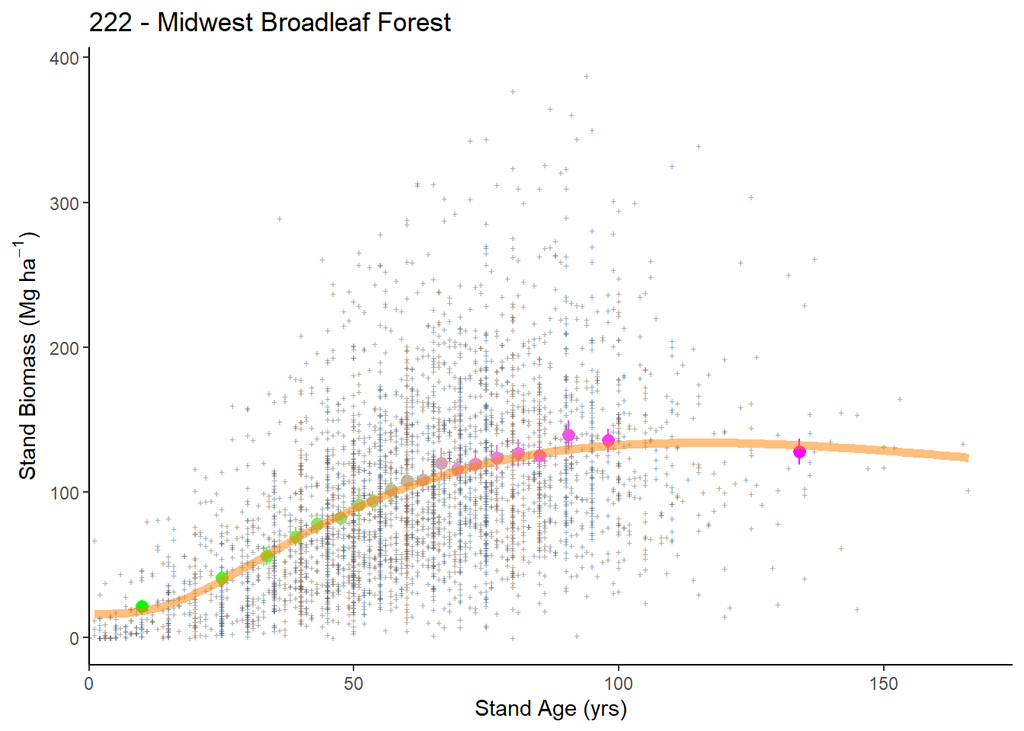

### plotting 2

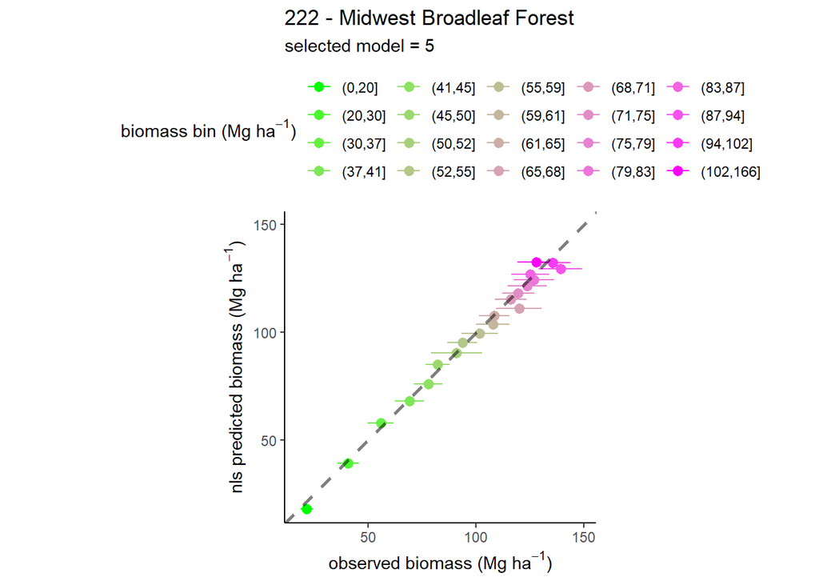

## 223 - Central Interior Broadleaf Forest

### model selection 1

```
## Analysis of Variance Table
##
## Model 1: B_plt_t2_MgHa ~ (1 + (MEASTIME_t2 - 1990) * tau/100) * A * STDAGE_t2/(k + STDAGE_t2)
## Model 2: B_plt_t2_MgHa ~ (1 + (MEASTIME_t2 - 1990) * tau/100) * (1 - alpha * B_L_prop) * A * STDAGE_t2/(k + STDAGE_t2)
##   Res.Df Res.Sum Sq Df Sum Sq F value    Pr(>F)
## 1   6383     1208.6
## 2   6382     1143.1  1 65.521  365.81 < 2.2e-16 ***
## ---
## Signif. codes:  0 '***' 0.001 '**' 0.01 '*' 0.05 '.' 0.1 ' ' 1
##   model      AIC
## 1     1 66739.63
## 2     2 66385.70
```

```
##
## Formula: B_plt_t2_MgHa ~ (1 + (MEASTIME_t2 - 1990) * tau/100) * (1 - alpha *
##     B_L_prop) * A * STDAGE_t2/(k + STDAGE_t2)
##
## Parameters:
##        Estimate Std. Error t value Pr(>|t|)
## tau     0.80821    0.12030   6.718    2e-11 ***
## alpha   0.70093    0.03432  20.426   <2e-16 ***
## A     212.97304    8.46135  25.170   <2e-16 ***
## k      72.75583    3.94421  18.446   <2e-16 ***
## ---
## Signif. codes:  0 '***' 0.001 '**' 0.01 '*' 0.05 '.' 0.1 ' ' 1
##
## Residual standard error: 0.4232 on 6382 degrees of freedom
##
## Number of iterations to convergence: 5
## Achieved convergence tolerance: 2.25e-06
##   (2 observations deleted due to missingness)
```

#### summary

- simple model: fits
- alpha model: fits

### model selection 2

```
## Analysis of Variance Table
##
## Model 1: B_plt_t2_MgHa ~ (1 + (MEASTIME_t2 - 1990) * tau/100) * (1 - alpha * B_L_prop) * A * STDAGE_t2/(k + STDAGE_t2)
## Model 2: B_plt_t2_MgHa ~ (1 + (MEASTIME_t2 - 1990) * tau/100) * (1 - alpha * B_L_prop) * (p * A + ((1 - p) * A * STDAGE_t2/(k + STDAGE_t2)))
## Model 3: B_plt_t2_MgHa ~ (1 + (MEASTIME_t2 - 1990) * tau/100) * (1 - alpha * B_L_prop) * (A * STDAGE_t2^s/(k^s + STDAGE_t2^s))
## Model 4: B_plt_t2_MgHa ~ (1 + (MEASTIME_t2 - 1990) * tau/100) * (1 - alpha * B_L_prop) * (p * A + ((1 - p) * A * STDAGE_t2^s/(k^s + STDAGE_t2^s)))
##   Res.Df Res.Sum Sq Df Sum Sq F value    Pr(>F)
## 1   6382     1143.1
## 2   6381     1142.5  1 0.6350  3.5469    0.0597 .
## 3   6381     1136.2  0 0.0000
## 4   6380     1128.1  1 8.1539 46.1159 1.215e-11 ***
## ---
## Signif. codes:  0 '***' 0.001 '**' 0.01 '*' 0.05 '.' 0.1 ' ' 1
##   model      AIC
## 1     2 66385.70
## 2    2a 66384.15
## 3    2b 66349.16
## 4    2c 66305.16
```

```
##
## Formula: B_plt_t2_MgHa ~ (1 + (MEASTIME_t2 - 1990) * tau/100) * (1 - alpha *
##     B_L_prop) * (p * A + ((1 - p) * A * STDAGE_t2^s/(k^s + STDAGE_t2^s)))
##
## Parameters:
##        Estimate Std. Error t value Pr(>|t|)
## tau     0.85759    0.12173   7.045 2.05e-12 ***
## alpha   0.71209    0.03381  21.062  < 2e-16 ***
## A     127.11413    4.61707  27.531  < 2e-16 ***
## k      37.02397    1.25609  29.475  < 2e-16 ***
## p       0.14094    0.01883   7.486 8.09e-14 ***
## s       2.17271    0.15279  14.220  < 2e-16 ***
## ---
## Signif. codes:  0 '***' 0.001 '**' 0.01 '*' 0.05 '.' 0.1 ' ' 1
##
## Residual standard error: 0.4205 on 6380 degrees of freedom
##
## Number of iterations to convergence: 5
## Achieved convergence tolerance: 4.063e-06
##   (2 observations deleted due to missingness)
```

### summary

- add p model: fits
- add s model: fits
- add s+p model: fits

### model selection 3

```
## Analysis of Variance Table
##
## Model 1: B_plt_t2_MgHa ~ (1 + (MEASTIME_t2 - 1990) * tau/100) * (a + b * exp(-((log(STDAGE_t2/c))/d)^2))
## Model 2: B_plt_t2_MgHa ~ (1 + (MEASTIME_t2 - 1990) * tau/100) * (1 - alpha * B_L_prop) * (a + b * exp(-((log(STDAGE_t2/c))/d)^2))
##   Res.Df Res.Sum Sq Df Sum Sq F value    Pr(>F)
## 1   6381     1195.9
## 2   6380     1127.7  1 68.139   385.5 < 2.2e-16 ***
## ---
## Signif. codes:  0 '***' 0.001 '**' 0.01 '*' 0.05 '.' 0.1 ' ' 1
##   model      AIC
## 1    2c 66305.16
## 2     4 66675.81
## 3     5 66303.16
```

```
##
## Formula: B_plt_t2_MgHa ~ (1 + (MEASTIME_t2 - 1990) * tau/100) * (1 - alpha *
##     B_L_prop) * (a + b * exp(-((log(STDAGE_t2/c))/d)^2))
##
## Parameters:
##        Estimate Std. Error t value Pr(>|t|)
## tau     0.84613    0.12109   6.988 3.08e-12 ***
## alpha   0.71122    0.03383  21.023  < 2e-16 ***
## a      17.80094    2.07031   8.598  < 2e-16 ***
## b      98.51432    3.90582  25.222  < 2e-16 ***
## c     113.18502    6.98395  16.206  < 2e-16 ***
## d       1.44570    0.07453  19.398  < 2e-16 ***
## ---
## Signif. codes:  0 '***' 0.001 '**' 0.01 '*' 0.05 '.' 0.1 ' ' 1
##
## Residual standard error: 0.4204 on 6380 degrees of freedom
##
## Algorithm "port", convergence message: relative convergence (4)
##   (2 observations deleted due to missingness)
```

#### summary

- simple log-normal model: fits
- log-normal phi model: fits

### predict and plot

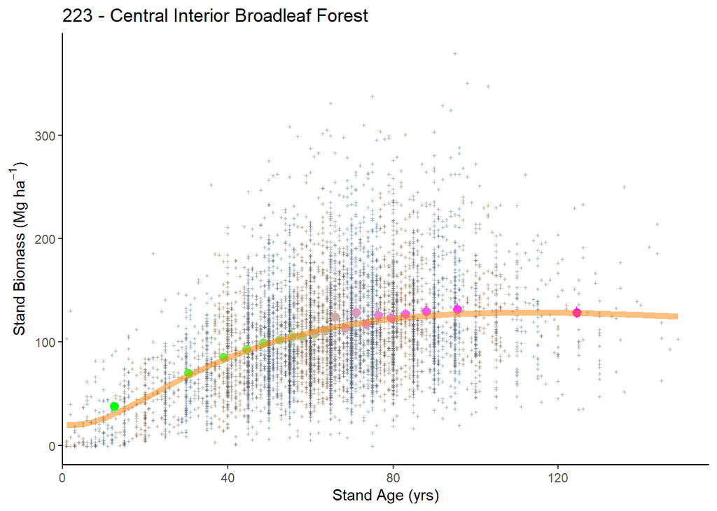

### plotting 2

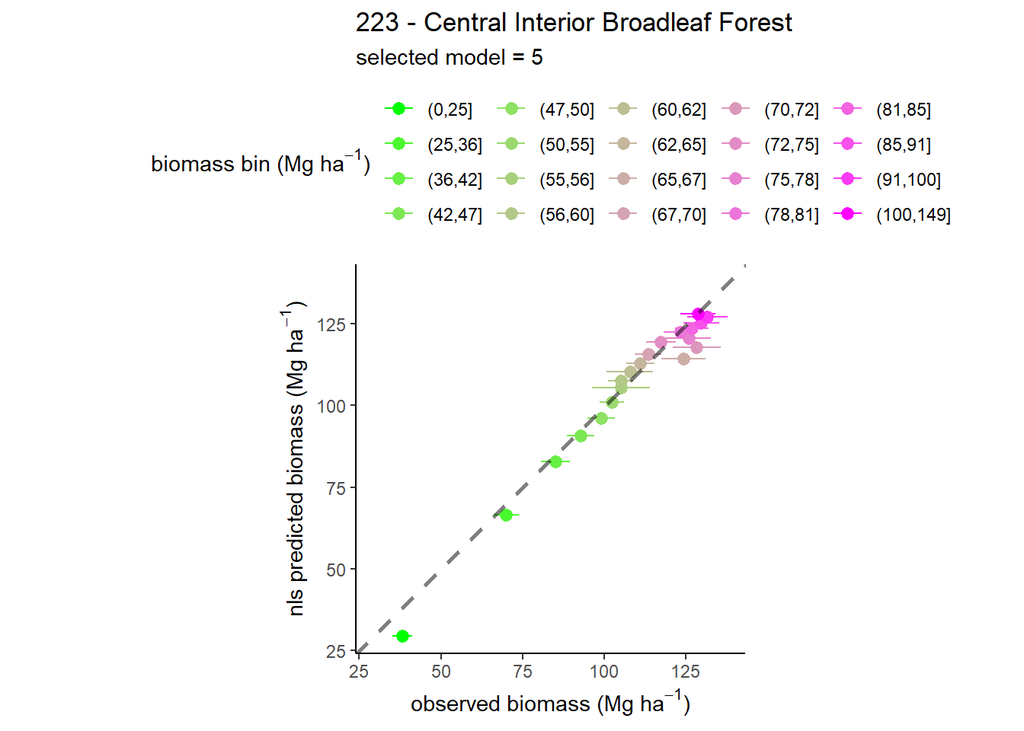

## 231 - Southeastern Mixed Forest

### model selection 1

```
## Analysis of Variance Table
##
## Model 1: B_plt_t2_MgHa ~ (1 + (MEASTIME_t2 - 1990) * tau/100) * A * STDAGE_t2/(k + STDAGE_t2)
## Model 2: B_plt_t2_MgHa ~ (1 + (MEASTIME_t2 - 1990) * tau/100) * (1 - alpha * B_L_prop) * A * STDAGE_t2/(k + STDAGE_t2)
##   Res.Df Res.Sum Sq Df Sum Sq F value    Pr(>F)
## 1   7773     2698.5
## 2   7772     2568.4  1 130.03  393.48 < 2.2e-16 ***
## ---
## Signif. codes:  0 '***' 0.001 '**' 0.01 '*' 0.05 '.' 0.1 ' ' 1
##   model      AIC
## 1     1 85845.56
## 2     2 85463.52
```

```
##
## Formula: B_plt_t2_MgHa ~ (1 + (MEASTIME_t2 - 1990) * tau/100) * (1 - alpha *
##     B_L_prop) * A * STDAGE_t2/(k + STDAGE_t2)
##
## Parameters:
##        Estimate Std. Error t value Pr(>|t|)
## tau     1.24476    0.17019   7.314 2.86e-13 ***
## alpha   0.57095    0.02662  21.444  < 2e-16 ***
## A     257.12975   11.27279  22.810  < 2e-16 ***
## k      67.16853    3.01370  22.288  < 2e-16 ***
## ---
## Signif. codes:  0 '***' 0.001 '**' 0.01 '*' 0.05 '.' 0.1 ' ' 1
##
## Residual standard error: 0.5749 on 7772 degrees of freedom
##
## Number of iterations to convergence: 6
## Achieved convergence tolerance: 1.572e-06
##   (14 observations deleted due to missingness)
```

#### summary

- simple model: fits
- alpha model: fits

### model selection 2

```
## Analysis of Variance Table
##
## Model 1: B_plt_t2_MgHa ~ (1 + (MEASTIME_t2 - 1990) * tau/100) * (1 - alpha * B_L_prop) * A * STDAGE_t2/(k + STDAGE_t2)
## Model 2: B_plt_t2_MgHa ~ (1 + (MEASTIME_t2 - 1990) * tau/100) * (1 - alpha * B_L_prop) * (p * A + ((1 - p) * A * STDAGE_t2/(k + STDAGE_t2)))
## Model 3: B_plt_t2_MgHa ~ (1 + (MEASTIME_t2 - 1990) * tau/100) * (1 - alpha * B_L_prop) * (A * STDAGE_t2^s/(k^s + STDAGE_t2^s))
## Model 4: B_plt_t2_MgHa ~ (1 + (MEASTIME_t2 - 1990) * tau/100) * (1 - alpha * B_L_prop) * (p * A + ((1 - p) * A * STDAGE_t2^s/(k^s + STDAGE_t2^s)))
##   Res.Df Res.Sum Sq Df Sum Sq F value    Pr(>F)
## 1   7772     2568.4
## 2   7771     2545.5  1 22.931  70.004 < 2.2e-16 ***
## 3   7771     2566.4  0  0.000
## 4   7770     2496.6  1 69.841 217.364 < 2.2e-16 ***
## ---
## Signif. codes:  0 '***' 0.001 '**' 0.01 '*' 0.05 '.' 0.1 ' ' 1
##   model      AIC
## 1     2 85463.52
## 2    2a 85395.79
## 3    2b 85459.40
## 4    2c 85246.85
```

```
##
## Formula: B_plt_t2_MgHa ~ (1 + (MEASTIME_t2 - 1990) * tau/100) * (1 - alpha *
##     B_L_prop) * (p * A + ((1 - p) * A * STDAGE_t2^s/(k^s + STDAGE_t2^s)))
##
## Parameters:
##        Estimate Std. Error t value Pr(>|t|)
## tau   1.506e+00  1.836e-01   8.201 2.76e-16 ***
## alpha 6.512e-01  2.258e-02  28.840  < 2e-16 ***
## A     1.450e+02  6.248e+00  23.205  < 2e-16 ***
## k     3.016e+01  1.222e+00  24.686  < 2e-16 ***
## p     1.076e-01  7.674e-03  14.024  < 2e-16 ***
## s     1.963e+00  9.744e-02  20.143  < 2e-16 ***
## ---
## Signif. codes:  0 '***' 0.001 '**' 0.01 '*' 0.05 '.' 0.1 ' ' 1
##
## Residual standard error: 0.5668 on 7770 degrees of freedom
##
## Number of iterations to convergence: 12
## Achieved convergence tolerance: 5.033e-06
##   (14 observations deleted due to missingness)
```

### summary

- add p model: fits
- add s model: fits
- add s+p model: fits

### model selection 3

```
## Analysis of Variance Table
##
## Model 1: B_plt_t2_MgHa ~ (1 + (MEASTIME_t2 - 1990) * tau/100) * (a + b * exp(-((log(STDAGE_t2/c))/d)^2))
## Model 2: B_plt_t2_MgHa ~ (1 + (MEASTIME_t2 - 1990) * tau/100) * (1 - alpha * B_L_prop) * (a + b * exp(-((log(STDAGE_t2/c))/d)^2))
##   Res.Df Res.Sum Sq Df Sum Sq F value    Pr(>F)
## 1   7771     2669.8
## 2   7770     2494.5  1 175.36  546.22 < 2.2e-16 ***
## ---
## Signif. codes:  0 '***' 0.001 '**' 0.01 '*' 0.05 '.' 0.1 ' ' 1
##   model      AIC
## 1    2c 85246.85
## 2     4 85766.57
## 3     5 85240.29
```

```
##
## Formula: B_plt_t2_MgHa ~ (1 + (MEASTIME_t2 - 1990) * tau/100) * (1 - alpha *
##     B_L_prop) * (a + b * exp(-((log(STDAGE_t2/c))/d)^2))
##
## Parameters:
##        Estimate Std. Error t value Pr(>|t|)
## tau     1.47599    0.18195   8.112 5.75e-16 ***
## alpha   0.65085    0.02255  28.860  < 2e-16 ***
## a      16.12785    0.82771  19.485  < 2e-16 ***
## b     120.36292    5.58045  21.569  < 2e-16 ***
## c     112.83900    9.26790  12.175  < 2e-16 ***
## d       1.63350    0.06625  24.657  < 2e-16 ***
## ---
## Signif. codes:  0 '***' 0.001 '**' 0.01 '*' 0.05 '.' 0.1 ' ' 1
##
## Residual standard error: 0.5666 on 7770 degrees of freedom
##
## Algorithm "port", convergence message: relative convergence (4)
##   (14 observations deleted due to missingness)
```

#### summary

- simple log-normal model: fits
- log-normal phi model: fits

### predict and plot

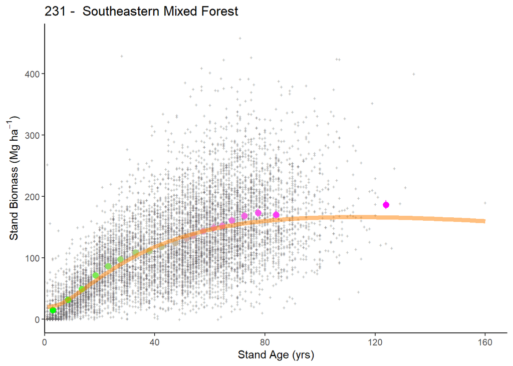

### plotting 2

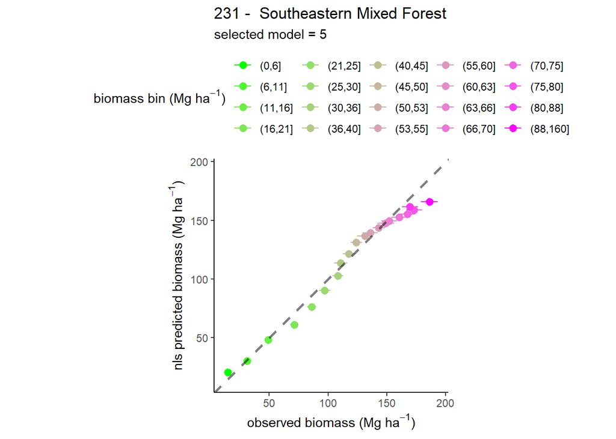

## 232 - Outer Coastal Plain Mixed Forest

### model selection 1

```
## Analysis of Variance Table
##
## Model 1: B_plt_t2_MgHa ~ (1 + (MEASTIME_t2 - 1990) * tau/100) * A * STDAGE_t2/(k + STDAGE_t2)
## Model 2: B_plt_t2_MgHa ~ (1 + (MEASTIME_t2 - 1990) * tau/100) * (1 - alpha * B_L_prop) * A * STDAGE_t2/(k + STDAGE_t2)
##   Res.Df Res.Sum Sq Df Sum Sq F value    Pr(>F)
## 1   7905     4072.2
## 2   7904     3928.6  1 143.61  288.94 < 2.2e-16 ***
## ---
## Signif. codes:  0 '***' 0.001 '**' 0.01 '*' 0.05 '.' 0.1 ' ' 1
##   model      AIC
## 1     1 88878.43
## 2     2 88596.51
```

```
##
## Formula: B_plt_t2_MgHa ~ (1 + (MEASTIME_t2 - 1990) * tau/100) * (1 - alpha *
##     B_L_prop) * A * STDAGE_t2/(k + STDAGE_t2)
##
## Parameters:
##        Estimate Std. Error t value Pr(>|t|)
## tau     0.76811    0.18004   4.266 2.01e-05 ***
## alpha   0.55314    0.02987  18.521  < 2e-16 ***
## A     270.07655   14.26944  18.927  < 2e-16 ***
## k      71.69928    3.93397  18.226  < 2e-16 ***
## ---
## Signif. codes:  0 '***' 0.001 '**' 0.01 '*' 0.05 '.' 0.1 ' ' 1
##
## Residual standard error: 0.705 on 7904 degrees of freedom
##
## Number of iterations to convergence: 6
## Achieved convergence tolerance: 1.137e-06
##   (32 observations deleted due to missingness)
```

#### summary

- simple model: fits
- alpha model: fits

### model selection 2

```
## Error in numericDeriv(form[[3L]], names(ind), env, central = nDcentral) :
##   Missing value or an infinity produced when evaluating the model
## Analysis of Variance Table
##
## Model 1: B_plt_t2_MgHa ~ (1 + (MEASTIME_t2 - 1990) * tau/100) * (1 - alpha * B_L_prop) * A * STDAGE_t2/(k + STDAGE_t2)
## Model 2: B_plt_t2_MgHa ~ (1 + (MEASTIME_t2 - 1990) * tau/100) * (1 - alpha * B_L_prop) * (p * A + ((1 - p) * A * STDAGE_t2/(k + STDAGE_t2)))
##   Res.Df Res.Sum Sq Df Sum Sq F value    Pr(>F)
## 1   7904     3928.6
## 2   7903     3859.0  1 69.597  142.53 < 2.2e-16 ***
## ---
## Signif. codes:  0 '***' 0.001 '**' 0.01 '*' 0.05 '.' 0.1 ' ' 1
##   model      AIC
## 1     2 88596.51
## 2    2a 88457.16
## 3    2b 88567.74
## 4    2c       NA
```

```
##
## Formula: B_plt_t2_MgHa ~ (1 + (MEASTIME_t2 - 1990) * tau/100) * (1 - alpha *
##     B_L_prop) * (p * A + ((1 - p) * A * STDAGE_t2/(k + STDAGE_t2)))
##
## Parameters:
##        Estimate Std. Error t value Pr(>|t|)
## tau   9.272e-01  1.885e-01   4.920 8.85e-07 ***
## alpha 6.432e-01  2.456e-02  26.191  < 2e-16 ***
## A     4.083e+02  4.091e+01   9.981  < 2e-16 ***
## k     1.596e+02  2.131e+01   7.489 7.67e-14 ***
## p     2.506e-02  1.901e-03  13.185  < 2e-16 ***
## ---
## Signif. codes:  0 '***' 0.001 '**' 0.01 '*' 0.05 '.' 0.1 ' ' 1
##
## Residual standard error: 0.6988 on 7903 degrees of freedom
##
## Number of iterations to convergence: 7
## Achieved convergence tolerance: 4.089e-06
##   (32 observations deleted due to missingness)
```

### summary

- add p model: fits
- add s model: fits
- add s+p model: does not fit

### model selection 3

```
## Analysis of Variance Table
##
## Model 1: B_plt_t2_MgHa ~ (1 + (MEASTIME_t2 - 1990) * tau/100) * (a + b * exp(-((log(STDAGE_t2/c))/d)^2))
## Model 2: B_plt_t2_MgHa ~ (1 + (MEASTIME_t2 - 1990) * tau/100) * (1 - alpha * B_L_prop) * (a + b * exp(-((log(STDAGE_t2/c))/d)^2))
##   Res.Df Res.Sum Sq Df Sum Sq F value    Pr(>F)
## 1   7903     4029.5
## 2   7902     3773.8  1 255.69  535.39 < 2.2e-16 ***
## ---
## Signif. codes:  0 '***' 0.001 '**' 0.01 '*' 0.05 '.' 0.1 ' ' 1
##   model      AIC
## 1    2a 88457.16
## 2     4 88799.14
## 3     5 88282.71
```

```
##
## Formula: B_plt_t2_MgHa ~ (1 + (MEASTIME_t2 - 1990) * tau/100) * (1 - alpha *
##     B_L_prop) * (a + b * exp(-((log(STDAGE_t2/c))/d)^2))
##
## Parameters:
##        Estimate Std. Error t value Pr(>|t|)
## tau     1.00852    0.19081   5.285 1.29e-07 ***
## alpha   0.71043    0.02138  33.233  < 2e-16 ***
## a      20.51866    1.02371  20.043  < 2e-16 ***
## b     121.27486    6.30094  19.247  < 2e-16 ***
## c     111.11452    9.25971  12.000  < 2e-16 ***
## d       1.50283    0.06832  21.998  < 2e-16 ***
## ---
## Signif. codes:  0 '***' 0.001 '**' 0.01 '*' 0.05 '.' 0.1 ' ' 1
##
## Residual standard error: 0.6911 on 7902 degrees of freedom
##
## Algorithm "port", convergence message: relative convergence (4)
##   (32 observations deleted due to missingness)
```

#### summary

- simple log-normal model: fits
- log-normal phi model: fits

### predict and plot

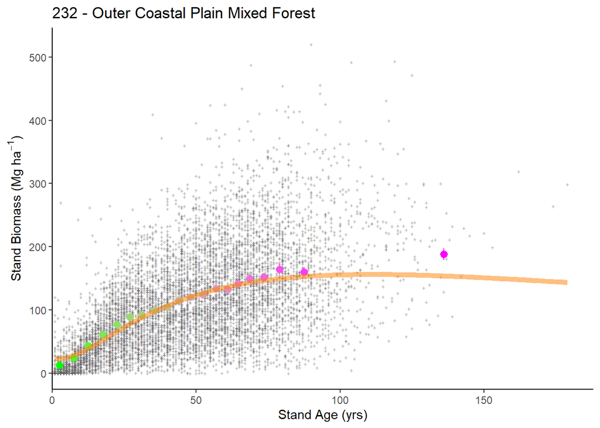

### plotting 2

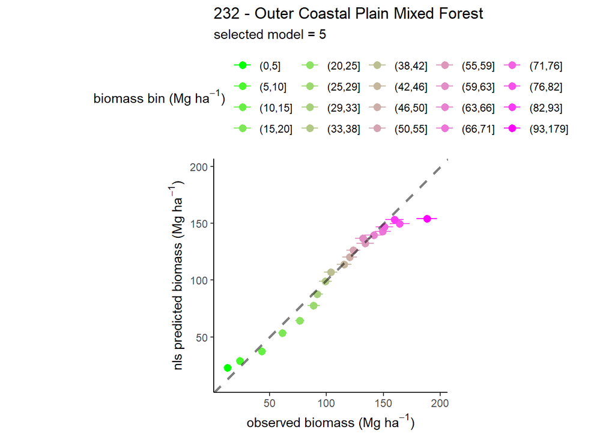

## 234 - Lower Mississippi Riverine Forest

### model selection 1

```
## Analysis of Variance Table
##
## Model 1: B_plt_t2_MgHa ~ (1 + (MEASTIME_t2 - 1990) * tau/100) * A * STDAGE_t2/(k + STDAGE_t2)
## Model 2: B_plt_t2_MgHa ~ (1 + (MEASTIME_t2 - 1990) * tau/100) * (1 - alpha * B_L_prop) * A * STDAGE_t2/(k + STDAGE_t2)
##   Res.Df Res.Sum Sq Df Sum Sq F value    Pr(>F)
## 1    826     218.04
## 2    825     194.59  1 23.448  99.412 < 2.2e-16 ***
## ---
## Signif. codes:  0 '***' 0.001 '**' 0.01 '*' 0.05 '.' 0.1 ' ' 1
##   model      AIC
## 1     1 9094.121
## 2     2 9001.802
```

```
##
## Formula: B_plt_t2_MgHa ~ (1 + (MEASTIME_t2 - 1990) * tau/100) * (1 - alpha *
##     B_L_prop) * A * STDAGE_t2/(k + STDAGE_t2)
##
## Parameters:
##        Estimate Std. Error t value Pr(>|t|)
## tau   3.865e-01  4.112e-01   0.940   0.3476
## alpha 7.628e-01  6.984e-02  10.922   <2e-16 ***
## A     1.255e+03  5.318e+02   2.360   0.0185 *
## k     4.893e+02  2.232e+02   2.192   0.0286 *
## ---
## Signif. codes:  0 '***' 0.001 '**' 0.01 '*' 0.05 '.' 0.1 ' ' 1
##
## Residual standard error: 0.4857 on 825 degrees of freedom
##
## Number of iterations to convergence: 7
## Achieved convergence tolerance: 1.631e-06
##   (1 observation deleted due to missingness)
```

#### summary

- simple model: fits
- alpha model: fits

### model selection 2

```
## Error in nls(get(paste("f_", Mod.Sel1, "a", sep = "")), data = G_234,  :
##   step factor 0.000488281 reduced below 'minFactor' of 0.000976562
## Error in numericDeriv(form[[3L]], names(ind), env, central = nDcentral) :
##   Missing value or an infinity produced when evaluating the model
## Analysis of Variance Table
##
## Model 1: B_plt_t2_MgHa ~ (1 + (MEASTIME_t2 - 1990) * tau/100) * (1 - alpha * B_L_prop) * A * STDAGE_t2/(k + STDAGE_t2)
## Model 2: B_plt_t2_MgHa ~ (1 + (MEASTIME_t2 - 1990) * tau/100) * (1 - alpha * B_L_prop) * (p * A + ((1 - p) * A * STDAGE_t2^s/(k^s + STDAGE_t2^s)))
##   Res.Df Res.Sum Sq Df Sum Sq F value  Pr(>F)
## 1    825     194.59
## 2    823     192.48  2 2.1059  4.5022 0.01136 *
## ---
## Signif. codes:  0 '***' 0.001 '**' 0.01 '*' 0.05 '.' 0.1 ' ' 1
##   model      AIC
## 1     2 9001.802
## 2    2a       NA
## 3    2b       NA
## 4    2c 8996.781
```

```
##
## Formula: B_plt_t2_MgHa ~ (1 + (MEASTIME_t2 - 1990) * tau/100) * (1 - alpha *
##     B_L_prop) * (p * A + ((1 - p) * A * STDAGE_t2^s/(k^s + STDAGE_t2^s)))
##
## Parameters:
##        Estimate Std. Error t value Pr(>|t|)
## tau     0.39536    0.41113   0.962    0.337
## alpha   0.78925    0.07021  11.242  < 2e-16 ***
## A     395.47217  189.29921   2.089    0.037 *
## k      99.96670   70.69953   1.414    0.158
## p      -0.01220    0.01423  -0.857    0.392
## s       1.13109    0.24438   4.628 4.28e-06 ***
## ---
## Signif. codes:  0 '***' 0.001 '**' 0.01 '*' 0.05 '.' 0.1 ' ' 1
##
## Residual standard error: 0.4836 on 823 degrees of freedom
##
## Number of iterations to convergence: 40
## Achieved convergence tolerance: 3.1e-06
##   (1 observation deleted due to missingness)
```

### summary

- add p model: does not fit
- add s model: does not fit
- add s+p model: fits

### model selection 3

```
## Analysis of Variance Table
##
## Model 1: B_plt_t2_MgHa ~ (1 + (MEASTIME_t2 - 1990) * tau/100) * (a + b * exp(-((log(STDAGE_t2/c))/d)^2))
## Model 2: B_plt_t2_MgHa ~ (1 + (MEASTIME_t2 - 1990) * tau/100) * (1 - alpha * B_L_prop) * (a + b * exp(-((log(STDAGE_t2/c))/d)^2))
##   Res.Df Res.Sum Sq Df Sum Sq F value    Pr(>F)
## 1    824     216.69
## 2    823     192.29  1 24.399  104.43 < 2.2e-16 ***
## ---
## Signif. codes:  0 '***' 0.001 '**' 0.01 '*' 0.05 '.' 0.1 ' ' 1
##   model      AIC
## 1    2c 8996.781
## 2     4 9092.966
## 3     5 8995.935
```

```
##
## Formula: B_plt_t2_MgHa ~ (1 + (MEASTIME_t2 - 1990) * tau/100) * (1 - alpha *
##     B_L_prop) * (a + b * exp(-((log(STDAGE_t2/c))/d)^2))
##
## Parameters:
##       Estimate Std. Error t value Pr(>|t|)
## tau     0.4024     0.4120   0.977  0.32908
## alpha   0.7883     0.0701  11.246  < 2e-16 ***
## a       0.0000     5.9324   0.000  1.00000
## b     340.8238   204.3728   1.668  0.09576 .
## c     675.4071   940.5067   0.718  0.47288
## d       2.5547     0.6884   3.711  0.00022 ***
## ---
## Signif. codes:  0 '***' 0.001 '**' 0.01 '*' 0.05 '.' 0.1 ' ' 1
##
## Residual standard error: 0.4834 on 823 degrees of freedom
##
## Algorithm "port", convergence message: relative convergence (4)
##   (1 observation deleted due to missingness)
```

#### summary

- simple log-normal model: fits
- log-normal phi model: fits

### predict and plot

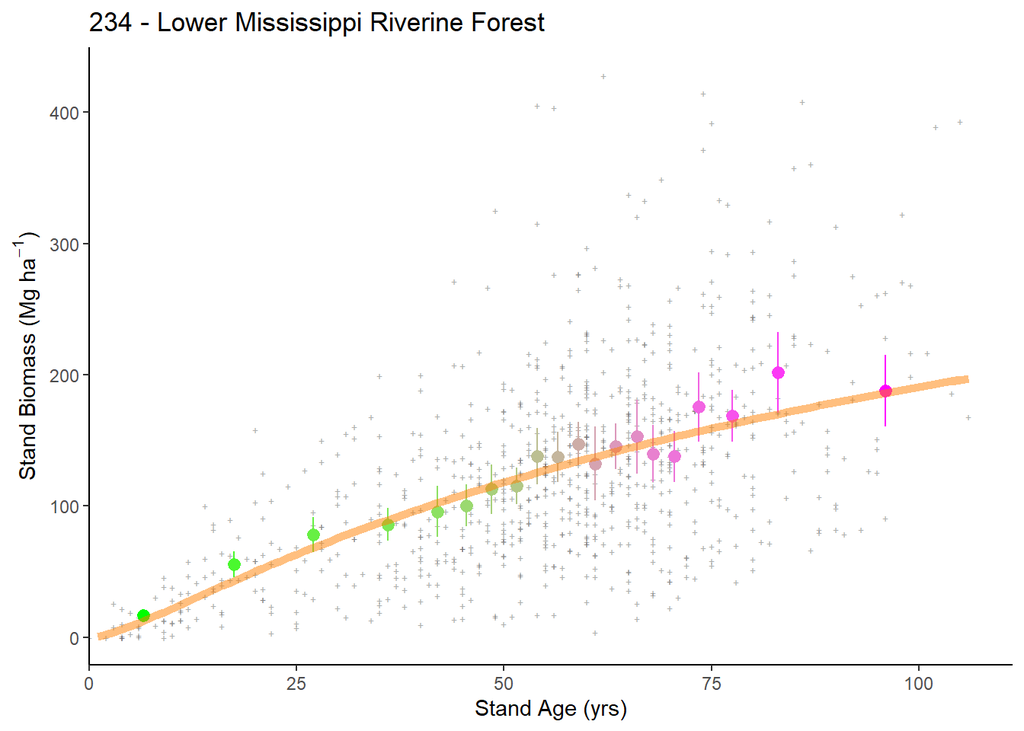

### plotting 2

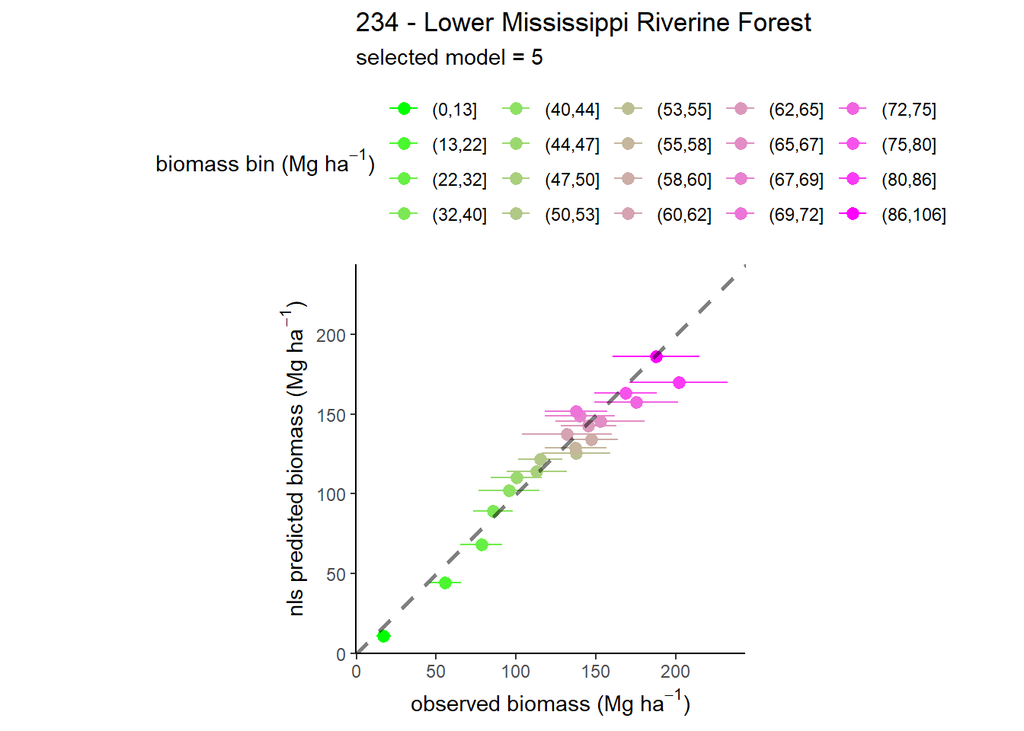

## 242 - Pacific Lowland Mixed Forest

### model selection 1

#### summary

- simple model: does not fit
- alpha model: does not fit

### model selection 2

### summary

- add p model: does not fit
- add s model: does not fit
- add s+p model: does not fit

### model selection 3

#### summary

- simple log-normal model: does not fit
- log-normal phi model: does not fit

### predict and plot

```
## [1] "cannot plot data with prediction"
```

### plotting 2

```
## [1] "cannot plot observed vs. predicted"
```

## 251 - Prairie Parkland (Temperate)

### model selection 1

```
## Analysis of Variance Table
##
## Model 1: B_plt_t2_MgHa ~ (1 + (MEASTIME_t2 - 1990) * tau/100) * A * STDAGE_t2/(k + STDAGE_t2)
## Model 2: B_plt_t2_MgHa ~ (1 + (MEASTIME_t2 - 1990) * tau/100) * (1 - alpha * B_L_prop) * A * STDAGE_t2/(k + STDAGE_t2)
##   Res.Df Res.Sum Sq Df Sum Sq F value    Pr(>F)
## 1   1387     347.56
## 2   1386     336.63  1 10.934   45.02 2.834e-11 ***
## ---
## Signif. codes:  0 '***' 0.001 '**' 0.01 '*' 0.05 '.' 0.1 ' ' 1
##   model      AIC
## 1     1 14526.30
## 2     2 14483.87
```

```
##
## Formula: B_plt_t2_MgHa ~ (1 + (MEASTIME_t2 - 1990) * tau/100) * (1 - alpha *
##     B_L_prop) * A * STDAGE_t2/(k + STDAGE_t2)
##
## Parameters:
##        Estimate Std. Error t value Pr(>|t|)
## tau     0.28977    0.25193   1.150     0.25
## alpha   0.68210    0.09544   7.147 1.43e-12 ***
## A     261.45525   28.66195   9.122  < 2e-16 ***
## k     106.87482   14.79744   7.223 8.39e-13 ***
## ---
## Signif. codes:  0 '***' 0.001 '**' 0.01 '*' 0.05 '.' 0.1 ' ' 1
##
## Residual standard error: 0.4928 on 1386 degrees of freedom
##
## Number of iterations to convergence: 5
## Achieved convergence tolerance: 9.101e-06
##   (2 observations deleted due to missingness)
```

#### summary

- simple model: fits
- alpha model: fits

### model selection 2

```
## Error in numericDeriv(form[[3L]], names(ind), env, central = nDcentral) :
##   Missing value or an infinity produced when evaluating the model
## Analysis of Variance Table
##
## Model 1: B_plt_t2_MgHa ~ (1 + (MEASTIME_t2 - 1990) * tau/100) * (1 - alpha * B_L_prop) * A * STDAGE_t2/(k + STDAGE_t2)
## Model 2: B_plt_t2_MgHa ~ (1 + (MEASTIME_t2 - 1990) * tau/100) * (1 - alpha * B_L_prop) * (p * A + ((1 - p) * A * STDAGE_t2/(k + STDAGE_t2)))
##   Res.Df Res.Sum Sq Df     Sum Sq F value Pr(>F)
## 1   1386     336.63
## 2   1385     336.63  1 5.7789e-05   2e-04 0.9877
##   model      AIC
## 1     2 14483.87
## 2    2a 14485.87
## 3    2b 14469.11
## 4    2c       NA
```

```
##
## Formula: B_plt_t2_MgHa ~ (1 + (MEASTIME_t2 - 1990) * tau/100) * (1 - alpha *
##     B_L_prop) * (A * STDAGE_t2^s/(k^s + STDAGE_t2^s))
##
## Parameters:
##        Estimate Std. Error t value Pr(>|t|)
## tau     0.34766    0.25540   1.361    0.174
## alpha   0.70227    0.09501   7.391 2.51e-13 ***
## A     142.90894   13.48623  10.597  < 2e-16 ***
## k      39.02880    3.98802   9.787  < 2e-16 ***
## s       1.74387    0.18179   9.593  < 2e-16 ***
## ---
## Signif. codes:  0 '***' 0.001 '**' 0.01 '*' 0.05 '.' 0.1 ' ' 1
##
## Residual standard error: 0.49 on 1385 degrees of freedom
##
## Number of iterations to convergence: 8
## Achieved convergence tolerance: 6.83e-06
##   (2 observations deleted due to missingness)
```

### summary

- add p model: fits
- add s model: fits
- add s+p model: does not fit

### model selection 3

```
## Analysis of Variance Table
##
## Model 1: B_plt_t2_MgHa ~ (1 + (MEASTIME_t2 - 1990) * tau/100) * (a + b * exp(-((log(STDAGE_t2/c))/d)^2))
## Model 2: B_plt_t2_MgHa ~ (1 + (MEASTIME_t2 - 1990) * tau/100) * (1 - alpha * B_L_prop) * (a + b * exp(-((log(STDAGE_t2/c))/d)^2))
##   Res.Df Res.Sum Sq Df Sum Sq F value    Pr(>F)
## 1   1385     337.23
## 2   1384     325.82  1 11.409  48.464 5.181e-12 ***
## ---
## Signif. codes:  0 '***' 0.001 '**' 0.01 '*' 0.05 '.' 0.1 ' ' 1
##   model      AIC
## 1    2b 14469.11
## 2     4 14488.37
## 3     5 14442.53
```

```
##
## Formula: B_plt_t2_MgHa ~ (1 + (MEASTIME_t2 - 1990) * tau/100) * (1 - alpha *
##     B_L_prop) * (a + b * exp(-((log(STDAGE_t2/c))/d)^2))
##
## Parameters:
##        Estimate Std. Error t value Pr(>|t|)
## tau     0.34162    0.25201   1.356    0.175
## alpha   0.70124    0.09431   7.435 1.82e-13 ***
## a      24.39435    4.05270   6.019 2.24e-09 ***
## b      93.28179    7.41989  12.572  < 2e-16 ***
## c     102.73710    8.92197  11.515  < 2e-16 ***
## d       1.13595    0.10865  10.455  < 2e-16 ***
## ---
## Signif. codes:  0 '***' 0.001 '**' 0.01 '*' 0.05 '.' 0.1 ' ' 1
##
## Residual standard error: 0.4852 on 1384 degrees of freedom
##
## Algorithm "port", convergence message: relative convergence (4)
##   (2 observations deleted due to missingness)
```

#### summary

- simple log-normal model: fits
- log-normal phi model: fits

### predict and plot

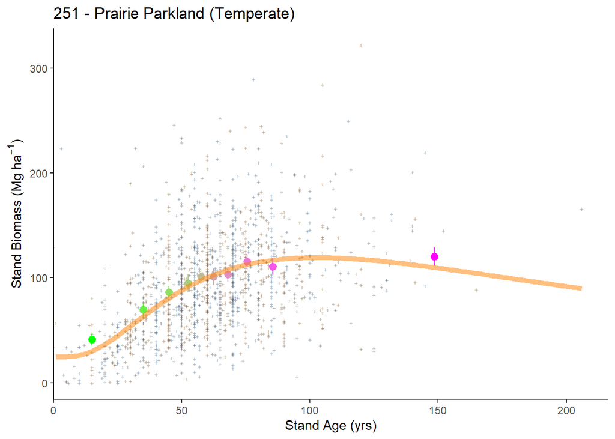

### plotting 2

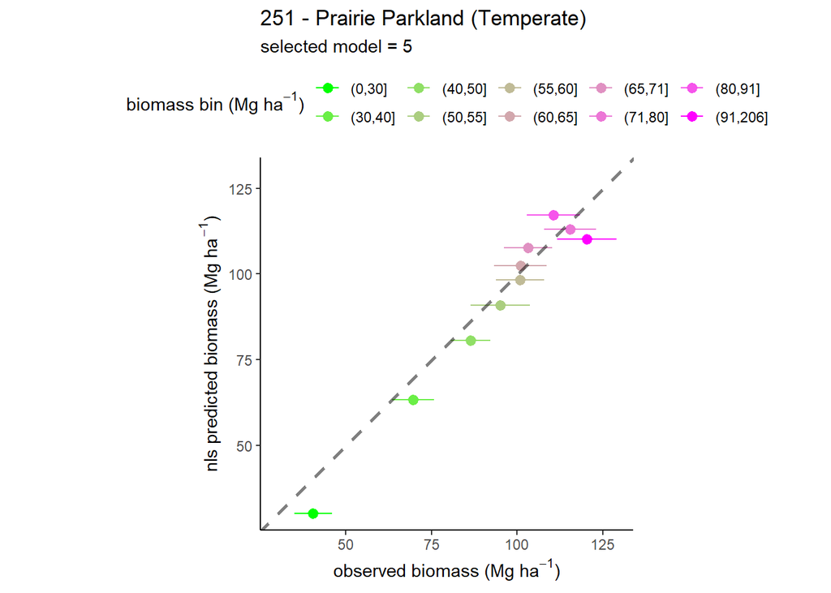

## 255 - Prairie Parkland (Subtropical)

### model selection 1

```
## Analysis of Variance Table
##
## Model 1: B_plt_t2_MgHa ~ (1 + (MEASTIME_t2 - 1990) * tau/100) * A * STDAGE_t2/(k + STDAGE_t2)
## Model 2: B_plt_t2_MgHa ~ (1 + (MEASTIME_t2 - 1990) * tau/100) * (1 - alpha * B_L_prop) * A * STDAGE_t2/(k + STDAGE_t2)
##   Res.Df Res.Sum Sq Df Sum Sq F value  Pr(>F)
## 1    439     237.09
## 2    438     235.09  1 2.0089  3.7429 0.05368 .
## ---
## Signif. codes:  0 '***' 0.001 '**' 0.01 '*' 0.05 '.' 0.1 ' ' 1
##   model      AIC
## 1     1 4609.958
## 2     2 4608.197
```

```
##
## Formula: B_plt_t2_MgHa ~ (1 + (MEASTIME_t2 - 1990) * tau/100) * (1 - alpha *
##     B_L_prop) * A * STDAGE_t2/(k + STDAGE_t2)
##
## Parameters:
##       Estimate Std. Error t value Pr(>|t|)
## tau    -0.1340     0.6019  -0.223  0.82393
## alpha   0.3504     0.1744   2.009  0.04512 *
## A     320.3752   106.7015   3.003  0.00283 **
## k     143.2259    52.7209   2.717  0.00686 **
## ---
## Signif. codes:  0 '***' 0.001 '**' 0.01 '*' 0.05 '.' 0.1 ' ' 1
##
## Residual standard error: 0.7326 on 438 degrees of freedom
##
## Number of iterations to convergence: 8
## Achieved convergence tolerance: 5.634e-06
##   (2 observations deleted due to missingness)
```

#### summary

- simple model: fits
- alpha model: fits

### model selection 2

```
## Error in numericDeriv(form[[3L]], names(ind), env, central = nDcentral) :
##   Missing value or an infinity produced when evaluating the model
## Error in numericDeriv(form[[3L]], names(ind), env, central = nDcentral) :
##   Missing value or an infinity produced when evaluating the model
## Analysis of Variance Table
##
## Model 1: B_plt_t2_MgHa ~ (1 + (MEASTIME_t2 - 1990) * tau/100) * (1 - alpha * B_L_prop) * A * STDAGE_t2/(k + STDAGE_t2)
## Model 2: B_plt_t2_MgHa ~ (1 + (MEASTIME_t2 - 1990) * tau/100) * (1 - alpha * B_L_prop) * (p * A + ((1 - p) * A * STDAGE_t2/(k + STDAGE_t2)))
##   Res.Df Res.Sum Sq Df Sum Sq F value Pr(>F)
## 1    438     235.09
## 2    437     234.74  1 0.3499  0.6514 0.4201
##   model      AIC
## 1     2 4608.197
## 2    2a 4609.539
## 3    2b       NA
## 4    2c       NA
```

```
##
## Formula: B_plt_t2_MgHa ~ (1 + (MEASTIME_t2 - 1990) * tau/100) * (1 - alpha *
##     B_L_prop) * A * STDAGE_t2/(k + STDAGE_t2)
##
## Parameters:
##       Estimate Std. Error t value Pr(>|t|)
## tau    -0.1340     0.6019  -0.223  0.82393
## alpha   0.3504     0.1744   2.009  0.04512 *
## A     320.3752   106.7015   3.003  0.00283 **
## k     143.2259    52.7209   2.717  0.00686 **
## ---
## Signif. codes:  0 '***' 0.001 '**' 0.01 '*' 0.05 '.' 0.1 ' ' 1
##
## Residual standard error: 0.7326 on 438 degrees of freedom
##
## Number of iterations to convergence: 8
## Achieved convergence tolerance: 5.634e-06
##   (2 observations deleted due to missingness)
```

### summary

- add p model: fits
- add s model: does not fit
- add s+p model: does not fit

### model selection 3

```
## Analysis of Variance Table
##
## Model 1: B_plt_t2_MgHa ~ (1 + (MEASTIME_t2 - 1990) * tau/100) * (a + b * exp(-((log(STDAGE_t2/c))/d)^2))
## Model 2: B_plt_t2_MgHa ~ (1 + (MEASTIME_t2 - 1990) * tau/100) * (1 - alpha * B_L_prop) * (a + b * exp(-((log(STDAGE_t2/c))/d)^2))
##   Res.Df Res.Sum Sq Df Sum Sq F value   Pr(>F)
## 1    437     226.64
## 2    436     221.69  1 4.9467  9.7286 0.001934 **
## ---
## Signif. codes:  0 '***' 0.001 '**' 0.01 '*' 0.05 '.' 0.1 ' ' 1
##   model      AIC
## 1     2 4608.197
## 2     4 4594.028
## 3     5 4586.274
```

```
##
## Formula: B_plt_t2_MgHa ~ (1 + (MEASTIME_t2 - 1990) * tau/100) * (1 - alpha *
##     B_L_prop) * (a + b * exp(-((log(STDAGE_t2/c))/d)^2))
##
## Parameters:
##       Estimate Std. Error t value Pr(>|t|)
## tau    -0.2440     0.5501  -0.443 0.657650
## alpha   0.5283     0.1577   3.350 0.000877 ***
## a       9.5645     1.9483   4.909 1.30e-06 ***
## b      88.5138    12.4743   7.096 5.24e-12 ***
## c      55.9913     5.9220   9.455  < 2e-16 ***
## d       1.0392     0.1138   9.129  < 2e-16 ***
## ---
## Signif. codes:  0 '***' 0.001 '**' 0.01 '*' 0.05 '.' 0.1 ' ' 1
##
## Residual standard error: 0.7131 on 436 degrees of freedom
##
## Algorithm "port", convergence message: relative convergence (4)
##   (2 observations deleted due to missingness)
```

#### summary

- simple log-normal model: fits
- log-normal phi model: fits

### predict and plot

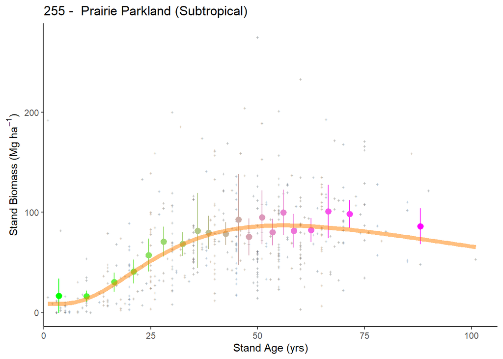

### plotting 2

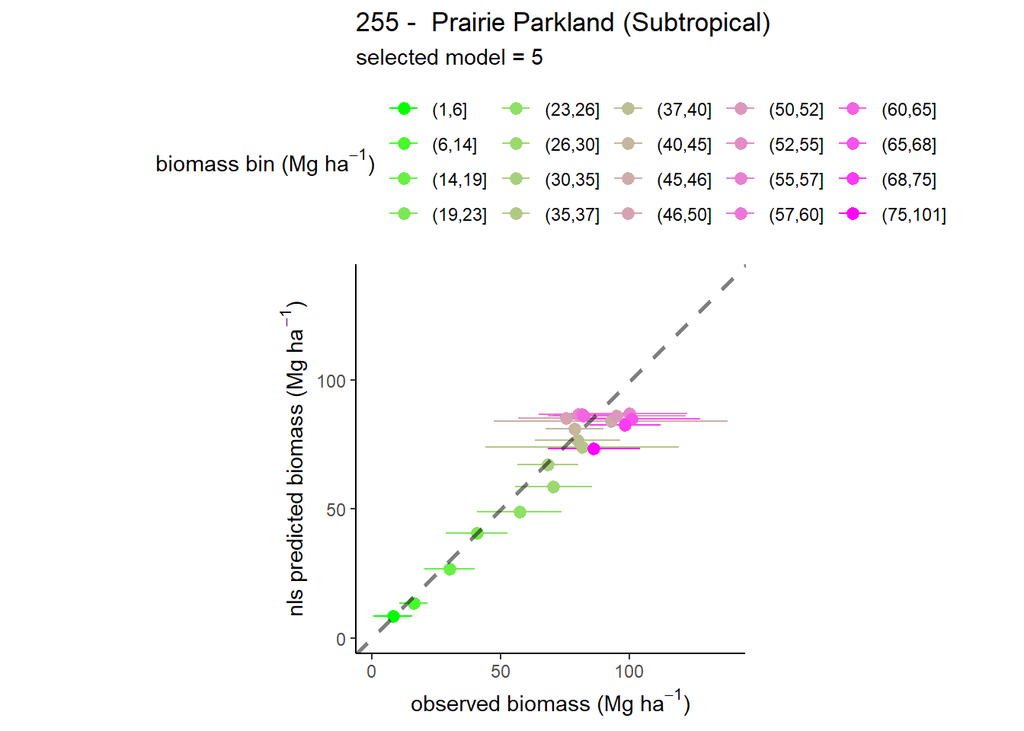

## 261 - California Coastal Chaparral Forest and Shrub

### model selection 1

#### summary

- simple model: does not fit
- alpha model: does not fit

### model selection 2

### summary

- add p model: does not fit
- add s model: does not fit
- add s+p model: does not fit
- unable to fit model (only 64 observations)

### model selection 3

#### summary

- simple log-normal model: does not fit
- log-normal phi model: does not fit

### predict and plot

```
## [1] "cannot plot data with prediction"
```

### plotting 2

```
## [1] "cannot plot observed vs. predicted"
```

## 262 - California Dry Steppe

### model selection 1

#### summary

- simple model: does not fit
- alpha model: does not fit

### model selection 2

### summary

- add p model: does not fit
- add s model: does not fit
- add s+p model: does not fit
- unable to fit model (0 observations)

### model selection 3

#### summary

- simple log-normal model: does not fit
- log-normal phi model: does not fit

### predict and plot

```
## [1] "cannot plot data with prediction"
```

### plotting 2

```
## [1] "cannot plot observed vs. predicted"
```

## 263 - California Coastal Steppe - Mixed Forest and Redwood Forest

### model selection 1

#### summary

- simple model: does not fit
- alpha model: does not fit

### model selection 2

### summary

- add p model: does not fit
- add s model: does not fit
- add s+p model: does not fit

### model selection 3

#### summary

- simple log-normal model: does not fit
- log-normal phi model: does not fit

### predict and plot

```
## [1] "cannot plot data with prediction"
```

### plotting 2

```
## [1] "cannot plot observed vs. predicted"
```

## 313 - Colorado Plateau Semi-Desert

### model selection 1

#### summary

- simple model: does not fit
- alpha model: does not fit

### model selection 2

### summary

- add p model: does not fit
- add s model: does not fit
- add s+p model: does not fit

### model selection 3

#### summary

- simple log-normal model: does not fit
- log-normal phi model: does not fit

### predict and plot

```
## [1] "cannot plot data with prediction"
```

### plotting 2

```
## [1] "cannot plot observed vs. predicted"
```

## 315 - Southwest Plateau and Plains Dry Steppe and Shrub

### model selection 1

#### summary

- simple model: does not fit
- alpha model: does not fit

### model selection 2

### summary

- add p model: does not fit
- add s model: does not fit
- add s+p model: does not fit

### model selection 3

#### summary

- simple log-normal model: does not fit
- log-normal phi model: does not fit

### predict and plot

```
## [1] "cannot plot data with prediction"
```

### plotting 2

```
## [1] "cannot plot observed vs. predicted"
```

## 321 - Chihuahuan Semi-Desert

### model selection 1

#### summary

- simple model: does not fit
- alpha model: does not fit

### model selection 2

### summary

- add p model: does not fit
- add s model: does not fit
- add s+p model: does not fit

### model selection 3

#### summary

- simple log-normal model: does not fit
- log-normal phi model: does not fit

### predict and plot

```
## [1] "cannot plot data with prediction"
```

### plotting 2

```
## [1] "cannot plot observed vs. predicted"
```

## 322 - American Semidesert and Desert

### model selection 1

```
## Error in if (any(nEQ <- vNms != make.names(vNms))) vNms[nEQ] <- paste0("`",  :
##   missing value where TRUE/FALSE needed
```

```
## Error in if (any(nEQ <- vNms != make.names(vNms))) vNms[nEQ] <- paste0("`",  :
##   missing value where TRUE/FALSE needed
```

```
##   model AIC
## 1     1  NA
## 2     2  NA
```

```
## Error in get(paste("nls_322.", Mod.Sel1, sep = "")) :
##   object 'nls_322.' not found
```

#### summary

- simple model: does not fit
- alpha model: does not fit

### model selection 2

### summary

- add p model: does not fit
- add s model: does not fit
- add s+p model: does not fit

### model selection 3

#### summary

- simple log-normal model: does not fit
- log-normal phi model: does not fit

### predict and plot

```
## [1] "cannot plot data with prediction"
```

### plotting 2

```
## [1] "cannot plot observed vs. predicted"
```

- Cannot fit model
- not enough data (only 3 observations)

## 331 - Great Plains/Palouse Dry Steppe

### model selection 1

#### summary

- simple model: does not fit
- alpha model: does not fit

### model selection 2

### summary

- add p model: does not fit
- add s model: does not fit
- add s+p model: does not fit

### model selection 3

#### summary

- simple log-normal model: does not fit
- log-normal phi model: does not fit

### predict and plot

```
## [1] "cannot plot data with prediction"
```

### plotting 2

```
## [1] "cannot plot observed vs. predicted"
```

- Cannot fit model

## 332 - Great Plains Steppe

### model selection 1

```
## Analysis of Variance Table
##
## Model 1: B_plt_t2_MgHa ~ (1 + (MEASTIME_t2 - 1990) * tau/100) * A * STDAGE_t2/(k + STDAGE_t2)
## Model 2: B_plt_t2_MgHa ~ (1 + (MEASTIME_t2 - 1990) * tau/100) * (1 - alpha * B_L_prop) * A * STDAGE_t2/(k + STDAGE_t2)
##   Res.Df Res.Sum Sq Df Sum Sq F value  Pr(>F)
## 1    149     87.775
## 2    148     83.201  1 4.5741  8.1365 0.00496 **
## ---
## Signif. codes:  0 '***' 0.001 '**' 0.01 '*' 0.05 '.' 0.1 ' ' 1
##   model      AIC
## 1     1 1640.707
## 2     2 1634.572
```

```
##
## Formula: B_plt_t2_MgHa ~ (1 + (MEASTIME_t2 - 1990) * tau/100) * (1 - alpha *
##     B_L_prop) * A * STDAGE_t2/(k + STDAGE_t2)
##
## Parameters:
##       Estimate Std. Error t value Pr(>|t|)
## tau     3.0055     4.1286   0.728  0.46779
## alpha   0.9714     0.2977   3.263  0.00137 **
## A     231.9254   226.9888   1.022  0.30857
## k     219.8242   199.9830   1.099  0.27346
## ---
## Signif. codes:  0 '***' 0.001 '**' 0.01 '*' 0.05 '.' 0.1 ' ' 1
##
## Residual standard error: 0.7498 on 148 degrees of freedom
##
## Number of iterations to convergence: 6
## Achieved convergence tolerance: 4.357e-06
##   (2 observations deleted due to missingness)
```

#### summary

- simple model: fits
- alpha model: fits

### model selection 2

```
## Error in nls(get(paste("f_", Mod.Sel1, "a", sep = "")), data = G_332,  :
##   number of iterations exceeded maximum of 50
## Error in numericDeriv(form[[3L]], names(ind), env, central = nDcentral) :
##   Missing value or an infinity produced when evaluating the model
## Analysis of Variance Table
##
## Model 1: B_plt_t2_MgHa ~ (1 + (MEASTIME_t2 - 1990) * tau/100) * (1 - alpha * B_L_prop) * A * STDAGE_t2/(k + STDAGE_t2)
## Model 2: B_plt_t2_MgHa ~ (1 + (MEASTIME_t2 - 1990) * tau/100) * (1 - alpha * B_L_prop) * (A * STDAGE_t2^s/(k^s + STDAGE_t2^s))
##   Res.Df Res.Sum Sq Df   Sum Sq F value Pr(>F)
## 1    148     83.201
## 2    147     83.108  1 0.093179  0.1648 0.6854
##   model      AIC
## 1     2 1634.572
## 2    2a       NA
## 3    2b 1636.402
## 4    2c       NA
```

```
##
## Formula: B_plt_t2_MgHa ~ (1 + (MEASTIME_t2 - 1990) * tau/100) * (1 - alpha *
##     B_L_prop) * A * STDAGE_t2/(k + STDAGE_t2)
##
## Parameters:
##       Estimate Std. Error t value Pr(>|t|)
## tau     3.0055     4.1286   0.728  0.46779
## alpha   0.9714     0.2977   3.263  0.00137 **
## A     231.9254   226.9888   1.022  0.30857
## k     219.8242   199.9830   1.099  0.27346
## ---
## Signif. codes:  0 '***' 0.001 '**' 0.01 '*' 0.05 '.' 0.1 ' ' 1
##
## Residual standard error: 0.7498 on 148 degrees of freedom
##
## Number of iterations to convergence: 6
## Achieved convergence tolerance: 4.357e-06
##   (2 observations deleted due to missingness)
```

### summary

- add p model: does not fit
- add s model: fits
- add s+p model: does not fit

### model selection 3

```
## Error in nls(f_5, data = G_332, start = c(tau = tau.start, alpha = alpha.start,  :
##   Convergence failure: iteration limit reached without convergence (10)
##   model      AIC
## 1     2 1634.572
## 2     4 1636.879
## 3     5       NA
```

```
##
## Formula: B_plt_t2_MgHa ~ (1 + (MEASTIME_t2 - 1990) * tau/100) * (1 - alpha *
##     B_L_prop) * A * STDAGE_t2/(k + STDAGE_t2)
##
## Parameters:
##       Estimate Std. Error t value Pr(>|t|)
## tau     3.0055     4.1286   0.728  0.46779
## alpha   0.9714     0.2977   3.263  0.00137 **
## A     231.9254   226.9888   1.022  0.30857
## k     219.8242   199.9830   1.099  0.27346
## ---
## Signif. codes:  0 '***' 0.001 '**' 0.01 '*' 0.05 '.' 0.1 ' ' 1
##
## Residual standard error: 0.7498 on 148 degrees of freedom
##
## Number of iterations to convergence: 6
## Achieved convergence tolerance: 4.357e-06
##   (2 observations deleted due to missingness)
```

#### summary

- simple log-normal model: fits
- log-normal phi model: does not fit

### predict and plot

[figure not shown]

### plotting 2

[figure not shown]

## 341 - Nevada-Utah Mountains Semi-Desert - Coniferous Forest - Alpine Meadow

### model selection 1

#### summary

- simple model: does not fit
- alpha model: does not fit

### model selection 2

### summary

- add p model: does not fit
- add s model: does not fit
- add s+p model: does not fit

### model selection 3

#### summary

- simple log-normal model: does not fit
- log-normal phi model: does not fit
- model not fitted because only 62 observations

### predict and plot

```
## [1] "cannot plot data with prediction"
```

### plotting 2

```
## [1] "cannot plot observed vs. predicted"
```

## 342 - Intermountain Semi-Desert

### model selection 1

#### summary

- simple model: does not fit
- alpha model: does not fit

### model selection 2

### summary

- add p model: does not fit
- add s model: does not fit
- add s+p model: does not fit

### model selection 3

#### summary

- simple log-normal model: does not fit
- log-normal phi model: does not fit

### predict and plot

```
## [1] "cannot plot data with prediction"
```

### plotting 2

```
## [1] "cannot plot observed vs. predicted"
```

## 411 - Everglades

### model selection 1

#### summary

- simple model: does not fit
- alpha model: does not fit

### model selection 2

### summary

- add p model: does not fit
- add s model: does not fit
- add s+p model: does not fit

### model selection 3

#### summary

- simple log-normal model: does not fit
- log-normal phi model: does not fit

### predict and plot

```
## [1] "cannot plot data with prediction"
```

### plotting 2

```
## [1] "cannot plot observed vs. predicted"
```

## M211 - Adirondack-New England Mixed forest - Coniferous Forest - Alpine Meadow

### model selection 1

```
## Analysis of Variance Table
##
## Model 1: B_plt_t2_MgHa ~ (1 + (MEASTIME_t2 - 1990) * tau/100) * A * STDAGE_t2/(k + STDAGE_t2)
## Model 2: B_plt_t2_MgHa ~ (1 + (MEASTIME_t2 - 1990) * tau/100) * (1 - alpha * B_L_prop) * A * STDAGE_t2/(k + STDAGE_t2)
##   Res.Df Res.Sum Sq Df Sum Sq F value    Pr(>F)
## 1   5103     963.25
## 2   5102     841.07  1 122.19  741.21 < 2.2e-16 ***
## ---
## Signif. codes:  0 '***' 0.001 '**' 0.01 '*' 0.05 '.' 0.1 ' ' 1
##   model      AIC
## 1     1 54262.24
## 2     2 53571.63
```

```
##
## Formula: B_plt_t2_MgHa ~ (1 + (MEASTIME_t2 - 1990) * tau/100) * (1 - alpha *
##     B_L_prop) * A * STDAGE_t2/(k + STDAGE_t2)
##
## Parameters:
##        Estimate Std. Error t value Pr(>|t|)
## tau     0.63454    0.16362   3.878 0.000107 ***
## alpha   0.80068    0.02686  29.811  < 2e-16 ***
## A     446.29921   29.09383  15.340  < 2e-16 ***
## k     198.11601   13.75314  14.405  < 2e-16 ***
## ---
## Signif. codes:  0 '***' 0.001 '**' 0.01 '*' 0.05 '.' 0.1 ' ' 1
##
## Residual standard error: 0.406 on 5102 degrees of freedom
##
## Number of iterations to convergence: 7
## Achieved convergence tolerance: 3.889e-06
##   (2 observations deleted due to missingness)
```

#### summary

- simple model: fits
- alpha model: fits

### model selection 2

```
## Error in numericDeriv(form[[3L]], names(ind), env, central = nDcentral) :
##   Missing value or an infinity produced when evaluating the model
## Error in numericDeriv(form[[3L]], names(ind), env, central = nDcentral) :
##   Missing value or an infinity produced when evaluating the model
## Analysis of Variance Table
##
## Model 1: B_plt_t2_MgHa ~ (1 + (MEASTIME_t2 - 1990) * tau/100) * (1 - alpha * B_L_prop) * A * STDAGE_t2/(k + STDAGE_t2)
## Model 2: B_plt_t2_MgHa ~ (1 + (MEASTIME_t2 - 1990) * tau/100) * (1 - alpha * B_L_prop) * (p * A + ((1 - p) * A * STDAGE_t2/(k + STDAGE_t2)))
##   Res.Df Res.Sum Sq Df Sum Sq F value    Pr(>F)
## 1   5102     841.07
## 2   5101     833.07  1 8.0008   48.99 2.905e-12 ***
## ---
## Signif. codes:  0 '***' 0.001 '**' 0.01 '*' 0.05 '.' 0.1 ' ' 1
##   model      AIC
## 1     2 53571.63
## 2    2a 53524.82
## 3    2b       NA
## 4    2c       NA
```

```
##
## Formula: B_plt_t2_MgHa ~ (1 + (MEASTIME_t2 - 1990) * tau/100) * (1 - alpha *
##     B_L_prop) * (p * A + ((1 - p) * A * STDAGE_t2/(k + STDAGE_t2)))
##
## Parameters:
##        Estimate Std. Error t value Pr(>|t|)
## tau     0.51537    0.15576   3.309 0.000944 ***
## alpha   0.81328    0.02703  30.083  < 2e-16 ***
## A     324.77328   20.26162  16.029  < 2e-16 ***
## k     102.66625   10.74934   9.551  < 2e-16 ***
## p      -0.05130    0.01127  -4.551 5.47e-06 ***
## ---
## Signif. codes:  0 '***' 0.001 '**' 0.01 '*' 0.05 '.' 0.1 ' ' 1
##
## Residual standard error: 0.4041 on 5101 degrees of freedom
##
## Number of iterations to convergence: 6
## Achieved convergence tolerance: 2.641e-06
##   (2 observations deleted due to missingness)
```

### summary

- add p model: fits
- add s model: does not fit
- add s+p model: does not fit

### model selection 3

```
## Analysis of Variance Table
##
## Model 1: B_plt_t2_MgHa ~ (1 + (MEASTIME_t2 - 1990) * tau/100) * (a + b * exp(-((log(STDAGE_t2/c))/d)^2))
## Model 2: B_plt_t2_MgHa ~ (1 + (MEASTIME_t2 - 1990) * tau/100) * (1 - alpha * B_L_prop) * (a + b * exp(-((log(STDAGE_t2/c))/d)^2))
##   Res.Df Res.Sum Sq Df Sum Sq F value    Pr(>F)
## 1   5101     952.58
## 2   5100     828.03  1 124.55  767.12 < 2.2e-16 ***
## ---
## Signif. codes:  0 '***' 0.001 '**' 0.01 '*' 0.05 '.' 0.1 ' ' 1
##   model      AIC
## 1    2a 53524.82
## 2     4 54209.36
## 3     5 53495.89
```

```
##
## Formula: B_plt_t2_MgHa ~ (1 + (MEASTIME_t2 - 1990) * tau/100) * (1 - alpha *
##     B_L_prop) * (a + b * exp(-((log(STDAGE_t2/c))/d)^2))
##
## Parameters:
##        Estimate Std. Error t value Pr(>|t|)
## tau     0.53028    0.15658   3.387 0.000713 ***
## alpha   0.81390    0.02671  30.470  < 2e-16 ***
## a      14.56503    2.98921   4.873 1.14e-06 ***
## b     155.65092   10.10200  15.408  < 2e-16 ***
## c     179.79825   19.79447   9.083  < 2e-16 ***
## d       1.58647    0.10396  15.261  < 2e-16 ***
## ---
## Signif. codes:  0 '***' 0.001 '**' 0.01 '*' 0.05 '.' 0.1 ' ' 1
##
## Residual standard error: 0.4029 on 5100 degrees of freedom
##
## Algorithm "port", convergence message: relative convergence (4)
##   (2 observations deleted due to missingness)
```

#### summary

- simple log-normal model: fits
- log-normal phi model: fits

### predict and plot

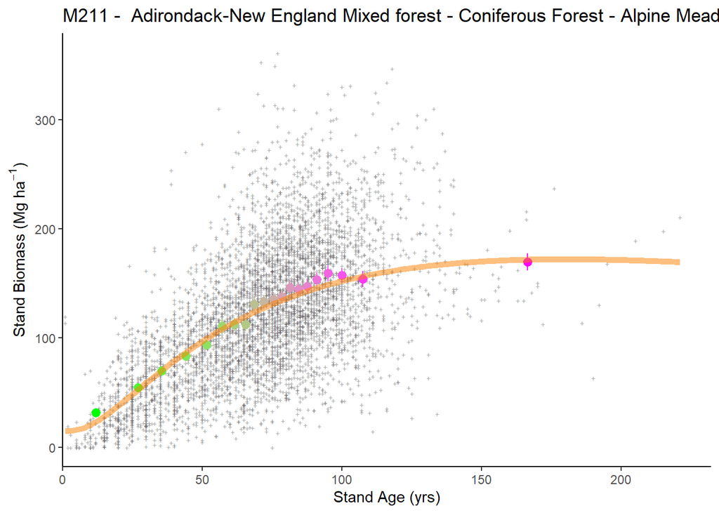

### plotting 2

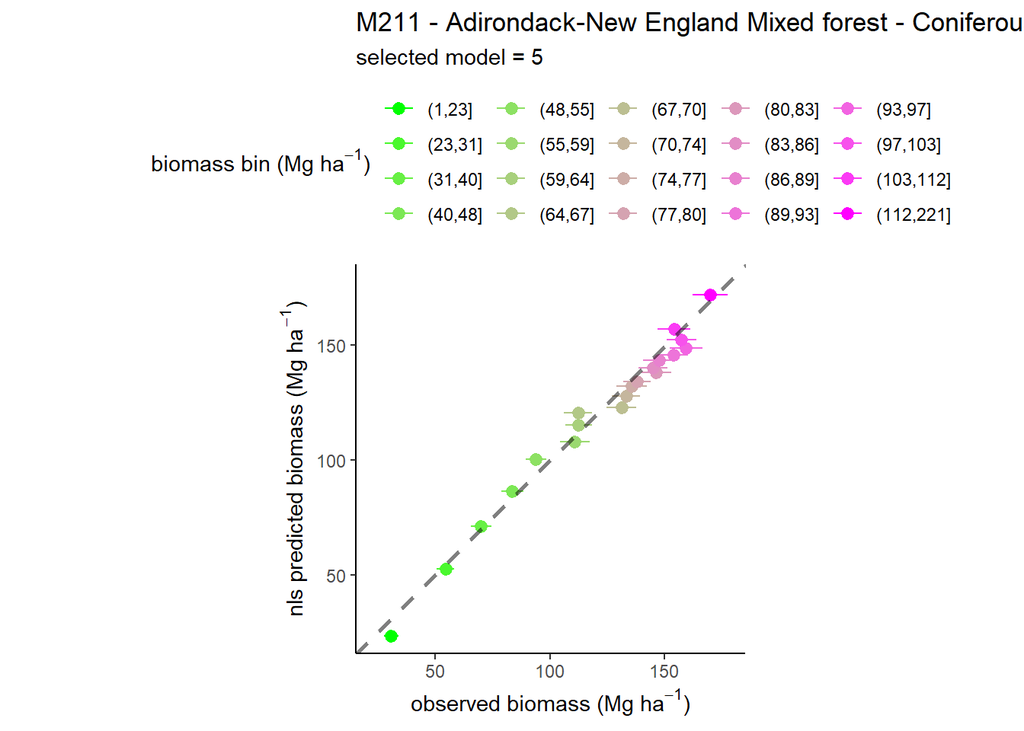

## M221 - Eastern Broadleaf Forest

### model selection 1

```
## Analysis of Variance Table
##
## Model 1: B_plt_t2_MgHa ~ (1 + (MEASTIME_t2 - 1990) * tau/100) * A * STDAGE_t2/(k + STDAGE_t2)
## Model 2: B_plt_t2_MgHa ~ (1 + (MEASTIME_t2 - 1990) * tau/100) * (1 - alpha * B_L_prop) * A * STDAGE_t2/(k + STDAGE_t2)
##   Res.Df Res.Sum Sq Df Sum Sq F value    Pr(>F)
## 1   5180     879.40
## 2   5179     824.61  1  54.79  344.11 < 2.2e-16 ***
## ---
## Signif. codes:  0 '***' 0.001 '**' 0.01 '*' 0.05 '.' 0.1 ' ' 1
##   model      AIC
## 1     1 57351.18
## 2     2 57019.77
```

```
##
## Formula: B_plt_t2_MgHa ~ (1 + (MEASTIME_t2 - 1990) * tau/100) * (1 - alpha *
##     B_L_prop) * A * STDAGE_t2/(k + STDAGE_t2)
##
## Parameters:
##        Estimate Std. Error t value Pr(>|t|)
## tau     0.69968    0.13285   5.267 1.45e-07 ***
## alpha   0.82371    0.04201  19.609  < 2e-16 ***
## A     266.46784   10.04611  26.524  < 2e-16 ***
## k      61.97132    3.14535  19.703  < 2e-16 ***
## ---
## Signif. codes:  0 '***' 0.001 '**' 0.01 '*' 0.05 '.' 0.1 ' ' 1
##
## Residual standard error: 0.399 on 5179 degrees of freedom
##
## Number of iterations to convergence: 7
## Achieved convergence tolerance: 3.081e-06
##   (3 observations deleted due to missingness)
```

#### summary

- simple model: fits
- alpha model: fits

### model selection 2

```
## Analysis of Variance Table
##
## Model 1: B_plt_t2_MgHa ~ (1 + (MEASTIME_t2 - 1990) * tau/100) * (1 - alpha * B_L_prop) * A * STDAGE_t2/(k + STDAGE_t2)
## Model 2: B_plt_t2_MgHa ~ (1 + (MEASTIME_t2 - 1990) * tau/100) * (1 - alpha * B_L_prop) * (p * A + ((1 - p) * A * STDAGE_t2/(k + STDAGE_t2)))
## Model 3: B_plt_t2_MgHa ~ (1 + (MEASTIME_t2 - 1990) * tau/100) * (1 - alpha * B_L_prop) * (A * STDAGE_t2^s/(k^s + STDAGE_t2^s))
## Model 4: B_plt_t2_MgHa ~ (1 + (MEASTIME_t2 - 1990) * tau/100) * (1 - alpha * B_L_prop) * (p * A + ((1 - p) * A * STDAGE_t2^s/(k^s + STDAGE_t2^s)))
##   Res.Df Res.Sum Sq Df  Sum Sq F value  Pr(>F)
## 1   5179     824.61
## 2   5178     823.80  1  0.8171  5.1361 0.02347 *
## 3   5178     817.30  0  0.0000
## 4   5177     805.02  1 12.2794 78.9674 < 2e-16 ***
## ---
## Signif. codes:  0 '***' 0.001 '**' 0.01 '*' 0.05 '.' 0.1 ' ' 1
##   model      AIC
## 1     2 57019.77
## 2    2a 57016.63
## 3    2b 56975.59
## 4    2c 56899.12
```

```
##
## Formula: B_plt_t2_MgHa ~ (1 + (MEASTIME_t2 - 1990) * tau/100) * (1 - alpha *
##     B_L_prop) * (p * A + ((1 - p) * A * STDAGE_t2^s/(k^s + STDAGE_t2^s)))
##
## Parameters:
##        Estimate Std. Error t value Pr(>|t|)
## tau     0.87739    0.14139   6.206 5.87e-10 ***
## alpha   0.82469    0.03959  20.832  < 2e-16 ***
## A     162.45200    5.61416  28.936  < 2e-16 ***
## k      37.03352    1.05271  35.179  < 2e-16 ***
## p       0.20173    0.01784  11.310  < 2e-16 ***
## s       2.64792    0.19044  13.904  < 2e-16 ***
## ---
## Signif. codes:  0 '***' 0.001 '**' 0.01 '*' 0.05 '.' 0.1 ' ' 1
##
## Residual standard error: 0.3943 on 5177 degrees of freedom
##
## Number of iterations to convergence: 6
## Achieved convergence tolerance: 1.479e-06
##   (3 observations deleted due to missingness)
```

### summary

- add p model: fits
- add s model: fits
- add s+p model: fits

### model selection 3

```
## Analysis of Variance Table
##
## Model 1: B_plt_t2_MgHa ~ (1 + (MEASTIME_t2 - 1990) * tau/100) * (a + b * exp(-((log(STDAGE_t2/c))/d)^2))
## Model 2: B_plt_t2_MgHa ~ (1 + (MEASTIME_t2 - 1990) * tau/100) * (1 - alpha * B_L_prop) * (a + b * exp(-((log(STDAGE_t2/c))/d)^2))
##   Res.Df Res.Sum Sq Df Sum Sq F value    Pr(>F)
## 1   5178     862.65
## 2   5177     803.67  1 58.977  379.91 < 2.2e-16 ***
## ---
## Signif. codes:  0 '***' 0.001 '**' 0.01 '*' 0.05 '.' 0.1 ' ' 1
##   model      AIC
## 1    2c 56899.12
## 2     4 57255.49
## 3     5 56890.45
```

```
##
## Formula: B_plt_t2_MgHa ~ (1 + (MEASTIME_t2 - 1990) * tau/100) * (1 - alpha *
##     B_L_prop) * (a + b * exp(-((log(STDAGE_t2/c))/d)^2))
##
## Parameters:
##        Estimate Std. Error t value Pr(>|t|)
## tau     0.87572    0.14097   6.212 5.64e-10 ***
## alpha   0.82430    0.03969  20.766  < 2e-16 ***
## a      31.76130    2.62008  12.122  < 2e-16 ***
## b     122.35089    4.61204  26.529  < 2e-16 ***
## c     103.12833    4.07801  25.289  < 2e-16 ***
## d       1.27367    0.05860  21.735  < 2e-16 ***
## ---
## Signif. codes:  0 '***' 0.001 '**' 0.01 '*' 0.05 '.' 0.1 ' ' 1
##
## Residual standard error: 0.394 on 5177 degrees of freedom
##
## Algorithm "port", convergence message: relative convergence (4)
##   (3 observations deleted due to missingness)
```

#### summary

- simple log-normal model: fits
- log-normal phi model: fits

### predict and plot

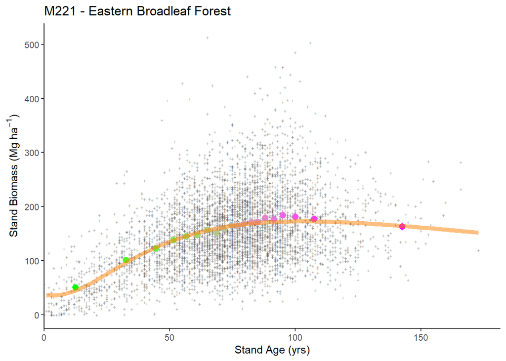

### plotting 2

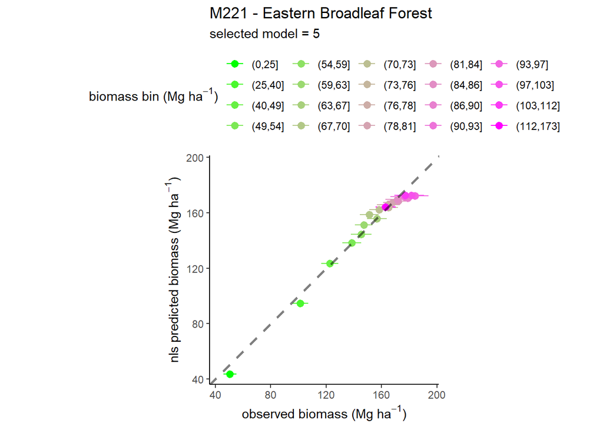

## M223 - Ozark Broadleaf Forest Meadow

### model selection 1

```
## Analysis of Variance Table
##
## Model 1: B_plt_t2_MgHa ~ (1 + (MEASTIME_t2 - 1990) * tau/100) * A * STDAGE_t2/(k + STDAGE_t2)
## Model 2: B_plt_t2_MgHa ~ (1 + (MEASTIME_t2 - 1990) * tau/100) * (1 - alpha * B_L_prop) * A * STDAGE_t2/(k + STDAGE_t2)
##   Res.Df Res.Sum Sq Df Sum Sq F value    Pr(>F)
## 1    596     80.866
## 2    595     71.900  1 8.9663    74.2 < 2.2e-16 ***
## ---
## Signif. codes:  0 '***' 0.001 '**' 0.01 '*' 0.05 '.' 0.1 ' ' 1
##   model      AIC
## 1     1 6115.535
## 2     2 6047.140
```

```
##
## Formula: B_plt_t2_MgHa ~ (1 + (MEASTIME_t2 - 1990) * tau/100) * (1 - alpha *
##     B_L_prop) * A * STDAGE_t2/(k + STDAGE_t2)
##
## Parameters:
##        Estimate Std. Error t value Pr(>|t|)
## tau    -0.07855    0.26298  -0.299    0.765
## alpha   0.89957    0.09748   9.228  < 2e-16 ***
## A     298.68647   41.73938   7.156 2.45e-12 ***
## k      95.82372   18.87728   5.076 5.16e-07 ***
## ---
## Signif. codes:  0 '***' 0.001 '**' 0.01 '*' 0.05 '.' 0.1 ' ' 1
##
## Residual standard error: 0.3476 on 595 degrees of freedom
##
## Number of iterations to convergence: 5
## Achieved convergence tolerance: 5.77e-06
##   (3 observations deleted due to missingness)
```

#### summary

- simple model: fits
- alpha model: fits

### model selection 2

```
## Error in nls(get(paste("f_", Mod.Sel1, "c", sep = "")), data = G_M223,  :
##   number of iterations exceeded maximum of 50
## Analysis of Variance Table
##
## Model 1: B_plt_t2_MgHa ~ (1 + (MEASTIME_t2 - 1990) * tau/100) * (1 - alpha * B_L_prop) * A * STDAGE_t2/(k + STDAGE_t2)
## Model 2: B_plt_t2_MgHa ~ (1 + (MEASTIME_t2 - 1990) * tau/100) * (1 - alpha * B_L_prop) * (p * A + ((1 - p) * A * STDAGE_t2/(k + STDAGE_t2)))
##   Res.Df Res.Sum Sq Df  Sum Sq F value Pr(>F)
## 1    595     71.900
## 2    594     71.708  1 0.19119  1.5837 0.2087
##   model      AIC
## 1     2 6047.140
## 2    2a 6047.545
## 3    2b 6048.497
## 4    2c       NA
```

```
##
## Formula: B_plt_t2_MgHa ~ (1 + (MEASTIME_t2 - 1990) * tau/100) * (1 - alpha *
##     B_L_prop) * A * STDAGE_t2/(k + STDAGE_t2)
##
## Parameters:
##        Estimate Std. Error t value Pr(>|t|)
## tau    -0.07855    0.26298  -0.299    0.765
## alpha   0.89957    0.09748   9.228  < 2e-16 ***
## A     298.68647   41.73938   7.156 2.45e-12 ***
## k      95.82372   18.87728   5.076 5.16e-07 ***
## ---
## Signif. codes:  0 '***' 0.001 '**' 0.01 '*' 0.05 '.' 0.1 ' ' 1
##
## Residual standard error: 0.3476 on 595 degrees of freedom
##
## Number of iterations to convergence: 5
## Achieved convergence tolerance: 5.77e-06
##   (3 observations deleted due to missingness)
```

### summary

- add p model: fits
- add s model: fits
- add s+p model: does not fit

### model selection 3

```
## Analysis of Variance Table
##
## Model 1: B_plt_t2_MgHa ~ (1 + (MEASTIME_t2 - 1990) * tau/100) * (a + b * exp(-((log(STDAGE_t2/c))/d)^2))
## Model 2: B_plt_t2_MgHa ~ (1 + (MEASTIME_t2 - 1990) * tau/100) * (1 - alpha * B_L_prop) * (a + b * exp(-((log(STDAGE_t2/c))/d)^2))
##   Res.Df Res.Sum Sq Df Sum Sq F value    Pr(>F)
## 1    594     80.723
## 2    593     71.768  1 8.9544  73.988 < 2.2e-16 ***
## ---
## Signif. codes:  0 '***' 0.001 '**' 0.01 '*' 0.05 '.' 0.1 ' ' 1
##   model      AIC
## 1     2 6047.140
## 2     4 6118.473
## 3     5 6050.044
```

```
##
## Formula: B_plt_t2_MgHa ~ (1 + (MEASTIME_t2 - 1990) * tau/100) * (1 - alpha *
##     B_L_prop) * A * STDAGE_t2/(k + STDAGE_t2)
##
## Parameters:
##        Estimate Std. Error t value Pr(>|t|)
## tau    -0.07855    0.26298  -0.299    0.765
## alpha   0.89957    0.09748   9.228  < 2e-16 ***
## A     298.68647   41.73938   7.156 2.45e-12 ***
## k      95.82372   18.87728   5.076 5.16e-07 ***
## ---
## Signif. codes:  0 '***' 0.001 '**' 0.01 '*' 0.05 '.' 0.1 ' ' 1
##
## Residual standard error: 0.3476 on 595 degrees of freedom
##
## Number of iterations to convergence: 5
## Achieved convergence tolerance: 5.77e-06
##   (3 observations deleted due to missingness)
```

#### summary

- simple log-normal model: fits
- log-normal phi model: fits

### predict and plot

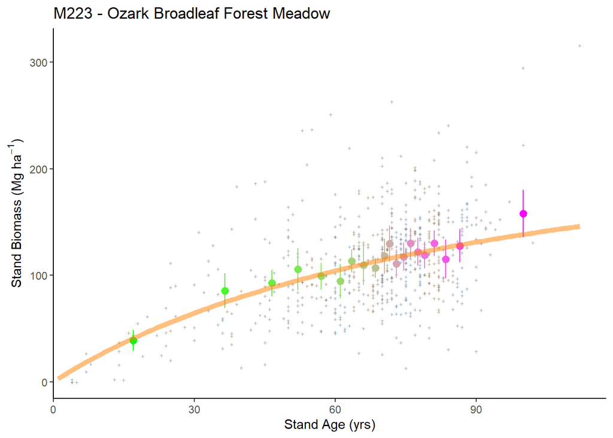

### plotting 2

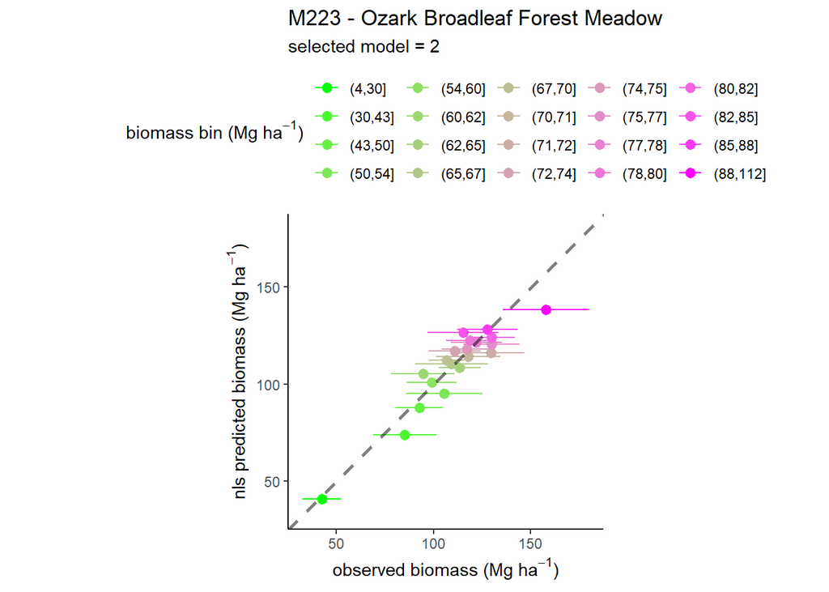

## M231 - Ouachita Mixed Forest

### model selection 1

```
## Analysis of Variance Table
##
## Model 1: B_plt_t2_MgHa ~ (1 + (MEASTIME_t2 - 1990) * tau/100) * A * STDAGE_t2/(k + STDAGE_t2)
## Model 2: B_plt_t2_MgHa ~ (1 + (MEASTIME_t2 - 1990) * tau/100) * (1 - alpha * B_L_prop) * A * STDAGE_t2/(k + STDAGE_t2)
##   Res.Df Res.Sum Sq Df Sum Sq F value    Pr(>F)
## 1    676     152.77
## 2    675     142.27  1 10.498  49.809 4.216e-12 ***
## ---
## Signif. codes:  0 '***' 0.001 '**' 0.01 '*' 0.05 '.' 0.1 ' ' 1
##   model      AIC
## 1     1 7025.553
## 2     2 6979.211
```

```
##
## Formula: B_plt_t2_MgHa ~ (1 + (MEASTIME_t2 - 1990) * tau/100) * (1 - alpha *
##     B_L_prop) * A * STDAGE_t2/(k + STDAGE_t2)
##
## Parameters:
##       Estimate Std. Error t value Pr(>|t|)
## tau     0.5697     0.5042   1.130    0.259
## alpha   0.8583     0.1139   7.536 1.57e-13 ***
## A     315.8268    62.8438   5.026 6.44e-07 ***
## k     147.8427    33.1149   4.465 9.40e-06 ***
## ---
## Signif. codes:  0 '***' 0.001 '**' 0.01 '*' 0.05 '.' 0.1 ' ' 1
##
## Residual standard error: 0.4591 on 675 degrees of freedom
##
## Number of iterations to convergence: 5
## Achieved convergence tolerance: 4.062e-06
##   (1 observation deleted due to missingness)
```

#### summary

- simple model: fits
- alpha model: fits

### model selection 2

```
## Analysis of Variance Table
##
## Model 1: B_plt_t2_MgHa ~ (1 + (MEASTIME_t2 - 1990) * tau/100) * (1 - alpha * B_L_prop) * A * STDAGE_t2/(k + STDAGE_t2)
## Model 2: B_plt_t2_MgHa ~ (1 + (MEASTIME_t2 - 1990) * tau/100) * (1 - alpha * B_L_prop) * (p * A + ((1 - p) * A * STDAGE_t2/(k + STDAGE_t2)))
## Model 3: B_plt_t2_MgHa ~ (1 + (MEASTIME_t2 - 1990) * tau/100) * (1 - alpha * B_L_prop) * (A * STDAGE_t2^s/(k^s + STDAGE_t2^s))
## Model 4: B_plt_t2_MgHa ~ (1 + (MEASTIME_t2 - 1990) * tau/100) * (1 - alpha * B_L_prop) * (p * A + ((1 - p) * A * STDAGE_t2^s/(k^s + STDAGE_t2^s)))
##   Res.Df Res.Sum Sq Df    Sum Sq F value Pr(>F)
## 1    675     142.27
## 2    674     142.26  1 0.0098593  0.0467 0.8290
## 3    674     142.26  0 0.0000000
## 4    673     142.26  1 0.0069224  0.0327 0.8564
##   model      AIC
## 1     2 6979.211
## 2    2a 6981.164
## 3    2b 6981.181
## 4    2c 6983.148
```

```
##
## Formula: B_plt_t2_MgHa ~ (1 + (MEASTIME_t2 - 1990) * tau/100) * (1 - alpha *
##     B_L_prop) * A * STDAGE_t2/(k + STDAGE_t2)
##
## Parameters:
##       Estimate Std. Error t value Pr(>|t|)
## tau     0.5697     0.5042   1.130    0.259
## alpha   0.8583     0.1139   7.536 1.57e-13 ***
## A     315.8268    62.8438   5.026 6.44e-07 ***
## k     147.8427    33.1149   4.465 9.40e-06 ***
## ---
## Signif. codes:  0 '***' 0.001 '**' 0.01 '*' 0.05 '.' 0.1 ' ' 1
##
## Residual standard error: 0.4591 on 675 degrees of freedom
##
## Number of iterations to convergence: 5
## Achieved convergence tolerance: 4.062e-06
##   (1 observation deleted due to missingness)
```

### summary

- add p model: fits
- add s model: fits
- add s+p model: fits

### model selection 3

```
## Error in nls(f_5, data = G_M231, start = c(tau = tau.start, alpha = alpha.start,  :
##   Convergence failure: iteration limit reached without convergence (10)
##   model      AIC
## 1     2 6979.211
## 2     4 7029.273
## 3     5       NA
```

```
##
## Formula: B_plt_t2_MgHa ~ (1 + (MEASTIME_t2 - 1990) * tau/100) * (1 - alpha *
##     B_L_prop) * A * STDAGE_t2/(k + STDAGE_t2)
##
## Parameters:
##       Estimate Std. Error t value Pr(>|t|)
## tau     0.5697     0.5042   1.130    0.259
## alpha   0.8583     0.1139   7.536 1.57e-13 ***
## A     315.8268    62.8438   5.026 6.44e-07 ***
## k     147.8427    33.1149   4.465 9.40e-06 ***
## ---
## Signif. codes:  0 '***' 0.001 '**' 0.01 '*' 0.05 '.' 0.1 ' ' 1
##
## Residual standard error: 0.4591 on 675 degrees of freedom
##
## Number of iterations to convergence: 5
## Achieved convergence tolerance: 4.062e-06
##   (1 observation deleted due to missingness)
```

#### summary

- simple log-normal model: fits
- log-normal phi model: does not fit

### predict and plot

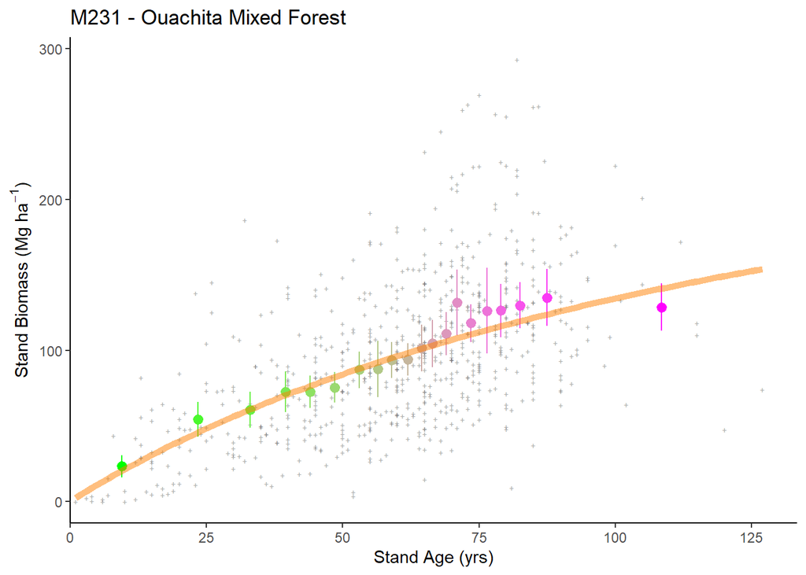

### plotting 2

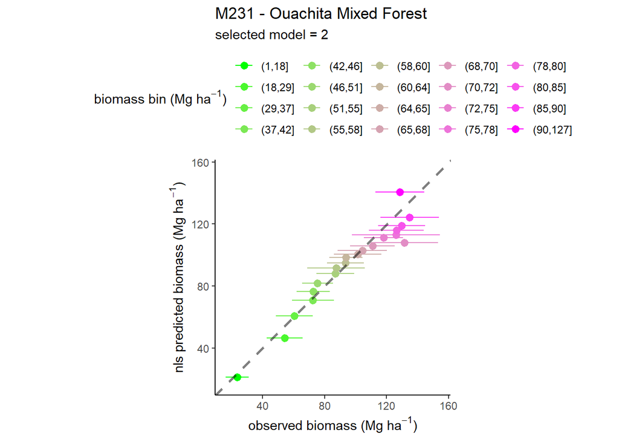

## M242 - Cascade Mixed Forest

### model selection 1

#### summary

- simple model: does not fit
- alpha model: does not fit

### model selection 2

### summary

- add p model: does not fit
- add s model: does not fit
- add s+p model: does not fit

### model selection 3

#### summary

- simple log-normal model: does not fit
- log-normal phi model: does not fit

### predict and plot

```
## [1] "cannot plot data with prediction"
```

### plotting 2

```
## [1] "cannot plot observed vs. predicted"
```

## M261 - Sierran Steppe - Mixed Forest - Coniferous Forest - Alpine Meadow

### model selection 1

```
## Analysis of Variance Table
##
## Model 1: B_plt_t2_MgHa ~ (1 + (MEASTIME_t2 - 1990) * tau/100) * A * STDAGE_t2/(k + STDAGE_t2)
## Model 2: B_plt_t2_MgHa ~ (1 + (MEASTIME_t2 - 1990) * tau/100) * (1 - alpha * B_L_prop) * A * STDAGE_t2/(k + STDAGE_t2)
##   Res.Df Res.Sum Sq Df Sum Sq F value  Pr(>F)
## 1    326    100.337
## 2    325     98.647  1 1.6905  5.5696 0.01887 *
## ---
## Signif. codes:  0 '***' 0.001 '**' 0.01 '*' 0.05 '.' 0.1 ' ' 1
##   model      AIC
## 1     1 3504.259
## 2     2 3500.669
```

```
##
## Formula: B_plt_t2_MgHa ~ (1 + (MEASTIME_t2 - 1990) * tau/100) * (1 - alpha *
##     B_L_prop) * A * STDAGE_t2/(k + STDAGE_t2)
##
## Parameters:
##       Estimate Std. Error t value Pr(>|t|)
## tau     1.5690     1.1894   1.319  0.18805
## alpha   0.6751     0.2661   2.537  0.01165 *
## A      85.0151    18.2427   4.660 4.61e-06 ***
## k      22.9171     7.8626   2.915  0.00381 **
## ---
## Signif. codes:  0 '***' 0.001 '**' 0.01 '*' 0.05 '.' 0.1 ' ' 1
##
## Residual standard error: 0.5509 on 325 degrees of freedom
##
## Number of iterations to convergence: 12
## Achieved convergence tolerance: 7.882e-06
##   (1 observation deleted due to missingness)
```

#### summary

- simple model: fits
- alpha model: fits

### model selection 2

```
## Analysis of Variance Table
##
## Model 1: B_plt_t2_MgHa ~ (1 + (MEASTIME_t2 - 1990) * tau/100) * (1 - alpha * B_L_prop) * A * STDAGE_t2/(k + STDAGE_t2)
## Model 2: B_plt_t2_MgHa ~ (1 + (MEASTIME_t2 - 1990) * tau/100) * (1 - alpha * B_L_prop) * (p * A + ((1 - p) * A * STDAGE_t2/(k + STDAGE_t2)))
## Model 3: B_plt_t2_MgHa ~ (1 + (MEASTIME_t2 - 1990) * tau/100) * (1 - alpha * B_L_prop) * (A * STDAGE_t2^s/(k^s + STDAGE_t2^s))
## Model 4: B_plt_t2_MgHa ~ (1 + (MEASTIME_t2 - 1990) * tau/100) * (1 - alpha * B_L_prop) * (p * A + ((1 - p) * A * STDAGE_t2^s/(k^s + STDAGE_t2^s)))
##   Res.Df Res.Sum Sq Df  Sum Sq F value Pr(>F)
## 1    325     98.647
## 2    324     97.539  1 1.10741  3.6785 0.0560 .
## 3    324     93.712  0 0.00000
## 4    323     93.308  1 0.40411  1.3989 0.2378
## ---
## Signif. codes:  0 '***' 0.001 '**' 0.01 '*' 0.05 '.' 0.1 ' ' 1
##   model      AIC
## 1     2 3500.669
## 2    2a 3498.954
## 3    2b 3485.785
## 4    2c 3486.363
```

```
##
## Formula: B_plt_t2_MgHa ~ (1 + (MEASTIME_t2 - 1990) * tau/100) * (1 - alpha *
##     B_L_prop) * (A * STDAGE_t2^s/(k^s + STDAGE_t2^s))
##
## Parameters:
##       Estimate Std. Error t value Pr(>|t|)
## tau     1.8945     1.2923   1.466   0.1436
## alpha   0.6580     0.2763   2.381   0.0178 *
## A      65.9248    13.3842   4.926 1.34e-06 ***
## k      30.8188     3.7464   8.226 4.75e-15 ***
## s      42.5340   187.7406   0.227   0.8209
## ---
## Signif. codes:  0 '***' 0.001 '**' 0.01 '*' 0.05 '.' 0.1 ' ' 1
##
## Residual standard error: 0.5378 on 324 degrees of freedom
##
## Number of iterations to convergence: 21
## Achieved convergence tolerance: 8.771e-06
##   (1 observation deleted due to missingness)
```

### summary

- add p model: fits
- add s model: fits
- add s+p model: fits

### model selection 3

```
## Analysis of Variance Table
##
## Model 1: B_plt_t2_MgHa ~ (1 + (MEASTIME_t2 - 1990) * tau/100) * (a + b * exp(-((log(STDAGE_t2/c))/d)^2))
## Model 2: B_plt_t2_MgHa ~ (1 + (MEASTIME_t2 - 1990) * tau/100) * (1 - alpha * B_L_prop) * (a + b * exp(-((log(STDAGE_t2/c))/d)^2))
##   Res.Df Res.Sum Sq Df Sum Sq F value  Pr(>F)
## 1    324     96.856
## 2    323     95.476  1   1.38  4.6688 0.03145 *
## ---
## Signif. codes:  0 '***' 0.001 '**' 0.01 '*' 0.05 '.' 0.1 ' ' 1
##   model      AIC
## 1    2b 3485.785
## 2     4 3496.641
## 3     5 3493.920
```

```
##
## Formula: B_plt_t2_MgHa ~ (1 + (MEASTIME_t2 - 1990) * tau/100) * (1 - alpha *
##     B_L_prop) * (A * STDAGE_t2^s/(k^s + STDAGE_t2^s))
##
## Parameters:
##       Estimate Std. Error t value Pr(>|t|)
## tau     1.8945     1.2923   1.466   0.1436
## alpha   0.6580     0.2763   2.381   0.0178 *
## A      65.9248    13.3842   4.926 1.34e-06 ***
## k      30.8188     3.7464   8.226 4.75e-15 ***
## s      42.5340   187.7406   0.227   0.8209
## ---
## Signif. codes:  0 '***' 0.001 '**' 0.01 '*' 0.05 '.' 0.1 ' ' 1
##
## Residual standard error: 0.5378 on 324 degrees of freedom
##
## Number of iterations to convergence: 21
## Achieved convergence tolerance: 8.771e-06
##   (1 observation deleted due to missingness)
```

#### summary

- simple log-normal model: fits
- log-normal phi model: fits

### predict and plot

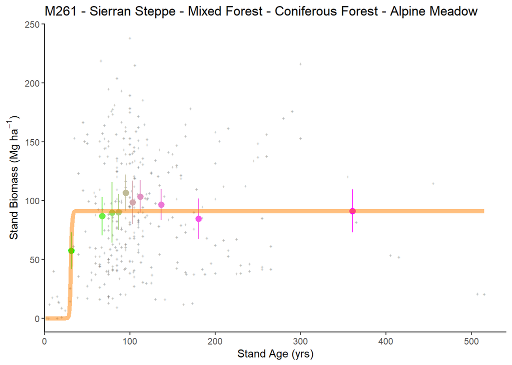

### plotting 2

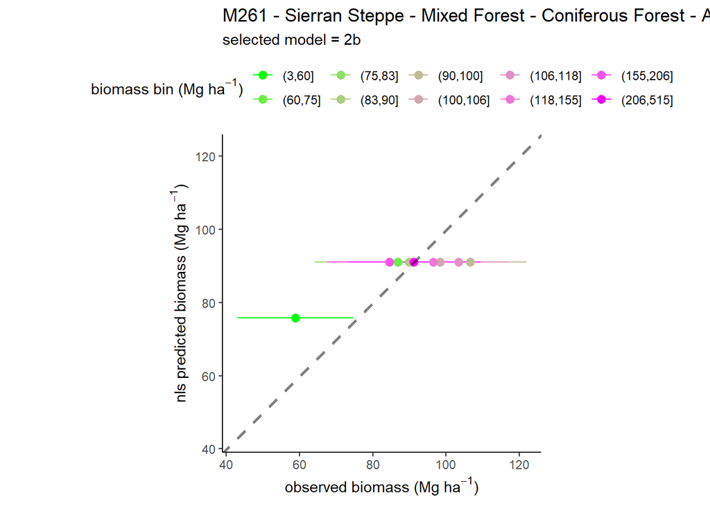

## M262 - California coastal range - coniferous forest - open woodland - shrub meadow

### Model selection 1

#### summary

- simple model: does not fit
- alpha model: does not fit

### model selection 2

### summary

- add p model: does not fit
- add s model: does not fit
- add s+p model: does not fit

### model selection 3

#### summary

- simple log-normal model: does not fit
- log-normal phi model: does not fit
- model can fit - but K is negative (only 19 observations) - model excluded

### predict and plot

```
## [1] "cannot plot data with prediction"
```

### plotting 2

## M313 - Arizona-New Mexico Mountains Semi-Desert - Open Woodland - Coniferous Forest - Alpine Meadow

### model selection 1

#### summary

- simple model: does not fit
- alpha model: does not fit

### model selection 2

### summary

- add p model: does not fit
- add s model: does not fit
- add s+p model: does not fit

### model selection 3

#### summary

- simple log-normal model: does not fit
- log-normal phi model: does not fit

### predict and plot

```
## [1] "cannot plot data with prediction"
```

### plotting 2

## M331 - Southern Rocky Mountain Steppe - Open Woodland - Coniferous Forest - Alpine Meadow

### model selection 1

#### summary

- simple model: does not fit
- alpha model: does not fit

### model selection 2

### summary

- add p model: does not fit
- add s model: does not fit
- add s+p model: does not fit

### model selection 3

#### summary

- simple log-normal model: does not fit
- log-normal phi model: does not fit

### predict and plot

```
## [1] "cannot plot data with prediction"
```

### plotting 2

## M332 - Middle Rocky Mountain Steppe - Coniferous Forest - Alpine Meadow

### model selection 1

#### summary

- simple model: does not fit
- alpha model: does not fit

### model selection 2

### summary

- add p model: does not fit
- add s model: does not fit
- add s+p model: does not fit

### model selection 3

#### summary

- simple log-normal model: does not fit
- log-normal phi model: does not fit

### predict and plot

```
## [1] "cannot plot data with prediction"
```

### plotting 2

## M333 - Northern Rocky Mountain Steppe - Coniferous Forest - Alpine Meadow

### model selection 1

#### summary

- simple model: does not fit
- alpha model: does not fit

### model selection 2

### summary

- add p model: does not fit
- add s model: does not fit
- add s+p model: does not fit

### model selection 3

#### summary

- simple log-normal model: does not fit
- log-normal phi model: does not fit

### predict and plot

```
## [1] "cannot plot data with prediction"
```

### plotting 2

## M334 - Black Hills Coniferous Forest

### model selection 1

```
## Analysis of Variance Table
##
## Model 1: B_plt_t2_MgHa ~ (1 + (MEASTIME_t2 - 1990) * tau/100) * A * STDAGE_t2/(k + STDAGE_t2)
## Model 2: B_plt_t2_MgHa ~ (1 + (MEASTIME_t2 - 1990) * tau/100) * (1 - alpha * B_L_prop) * A * STDAGE_t2/(k + STDAGE_t2)
##   Res.Df Res.Sum Sq Df Sum Sq F value    Pr(>F)
## 1    299     124.35
## 2    298     113.37  1 10.974  28.846 1.581e-07 ***
## ---
## Signif. codes:  0 '***' 0.001 '**' 0.01 '*' 0.05 '.' 0.1 ' ' 1
##   model      AIC
## 1     1 3013.807
## 2     2 2987.903
```

```
##
## Formula: B_plt_t2_MgHa ~ (1 + (MEASTIME_t2 - 1990) * tau/100) * (1 - alpha *
##     B_L_prop) * A * STDAGE_t2/(k + STDAGE_t2)
##
## Parameters:
##       Estimate Std. Error t value Pr(>|t|)
## tau    0.07662    0.66159   0.116  0.90788
## alpha  0.77829    0.12977   5.998 5.79e-09 ***
## A     99.54181   19.23214   5.176 4.18e-07 ***
## k     53.05797   17.65911   3.005  0.00289 **
## ---
## Signif. codes:  0 '***' 0.001 '**' 0.01 '*' 0.05 '.' 0.1 ' ' 1
##
## Residual standard error: 0.6168 on 298 degrees of freedom
##
## Number of iterations to convergence: 5
## Achieved convergence tolerance: 6.942e-06
##   (4 observations deleted due to missingness)
```

#### summary

- simple model: fits
- alpha model: fits